# Condition anaylsis

z-score T and F resids by location

Running lm(weight ~ length + …) for now for speed to get a feel for how slopes of the length/weight relationship vary across species and other variables. Will likely move to RE models next.

If newData, then will load raw files, parse, filter and save as ‘dat’

```r
newData = FALSE
date <- "June4"  #suffix for data subdirectory
```

Only need to run this with new data - data output as ‘dat’

```r
if (newData) {

    # bring in all of the fish size data
    fish <- list.files(paste0("D:/projects/ecoDrought/bodySize/All_Size_inputs/Size_inputs_",
        date), pattern = "*.txt", full.names = T)

    txt_files_df <- lapply(fish, function(x) {
        read.table(file = x, header = T, sep = ",")
    })

    all_fish <- do.call("rbind", lapply(txt_files_df, as.data.frame))

    ## bring in the covariate data
    covs <- read.csv("D:/projects/ecoDrought/bodySize/All_Size_inputs/covariates_size_analysis.csv")

    # merge fish data with covariate data
    all_fish_init <- merge(all_fish, covs, by = "RALLID")

    # Select only those fish of interest

    # species of interest
    sinc <- c("Bonneville Cutthroat Trout", "Colorado River Cutthroat Trout", "Redband Trout",
        "Bull Trout", "Brook Trout", "Mountain Whitefish", "Brown Trout", "Westslope Cutthroat Trout",
        "Yellowstone Cutthroat Trout", "Rainbow Trout")

    # exclude weir data
    nw <- c("Lake", "stream")

    dat0 <- all_fish_init %>% filter(species %in% sinc, site_type %in% nw, !is.na(Weight),
        Length > 75) %>% rename(weight = Weight, length = Length) %>% mutate(log10Weight = log10(weight),
        log10Length = log10(length))

    # Species-specific LWE regressions so we can add residuals to dataset
    lwModel <- function(df) {
        lm(log10Weight ~ log10Length, data = df)
    }

    datBySpecies <- dat0 %>% group_by(species) %>% nest() %>% mutate(model = map(data,
        lwModel))

    datBySpecies <- datBySpecies %>% mutate(resids = map2(data, model, add_residuals))

    dat <- dt_unnest(datBySpecies, resids)  # unnest() from tidyverse is so slow it never finishes

    dat <- dat %>% group_by(location) %>% mutate(daStd = (log(drain_area_km2) - (mean(log(drain_area_km2))))/sd(log(drain_area_km2)),
        sFStd = (log(summerF) - (mean(log(summerF + 1e-04), na.rm = TRUE)))/sd(log(summerF +
            1e-04), na.rm = TRUE), sTStd = (log(summerT) - (mean(log(summerT), na.rm = TRUE)))/sd(log(summerT),
            na.rm = TRUE), slopeStd = (SLOPE - mean(SLOPE))/sd(SLOPE), rdStd = (log(rel_density) -
            (mean(log(rel_density), na.rm = TRUE)))/sd(log(rel_density), na.rm = TRUE)) %>%
        ungroup()

    speciesList <- unique(dat$species)

    save(dat, file = paste0("D:/projects/ecoDrought/bodySize/All_Size_inputs/Size_inputs_",
        date, "/dat.R"))

    rm(all_fish_init, all_fish, dat0)
}
```

```r
if (newData) {
    for (i in c(1, 2, 4, 5, 6, 7, 8, 9)) {
        print(i)

        ggplot(dat %>% filter(species %in% c(sinc[i])), aes(log10Length, log10Weight,
            color = Lake)) + geom_point(alpha = 0.1) + geom_smooth(method = "lm") +
            facet_wrap(~species)

        ggsave(paste0("D:/projects/ecoDrought/bodySize/All_Size_inputs/ecoDrought_conditionAnalysis/charts/LW_",
            sinc[i], ".png"))

        ggplot(dat %>% filter(species == "Brown Trout"), aes(log10Length, log10Weight,
            color = Location)) + # geom_point(alpha = 0.1) +
        geom_smooth(aes(linetype = factor(Lake)), method = "lm") + facet_wrap(~species)

    }
}
```

```r
if (!newData) {
    load(paste0("D:/projects/ecoDrought/bodySize/All_Size_inputs/Size_inputs_", date,
        "/dat.R"))
    speciesList <- unique(dat$species)
}
```

# LW relationship analysis section

## Species differences

Species have significantly different LW relationships, although LW regression lines overlap considerably. No random effects yet - lmer takes a long time to run (may try bam, https://m-clark.github.io/posts/2019-10-20-big-mixed-models/)

```r
if (newData) {
    ggplot(dat, aes(log10Length, log10Weight, color = species)) + geom_point(alpha = 0.01) +
        geom_smooth(method = "lm")

    ggsave(paste0("D:/projects/ecoDrought/bodySize/All_Size_inputs/ecoDrought_conditionAnalysis/charts/LWbySpecies.png"))
}

# modSpp1 <- lmer(log10Weight ~ log10Length * species + 1|HUC8_Name, data = dat)
# very slow
modSpp0 <- lm(log10Weight ~ log10Length, data = dat)
modSpp1 <- lm(log10Weight ~ log10Length * species, data = dat)


AIC(modSpp0, modSpp1)
```

```
##         df      AIC
## modSpp0  3 -5536382
## modSpp1 19 -5655099
```

```r
# species have different slopes and intercepts
kable(anova(modSpp1)) %>% kable_styling(font_size = 12)
```

|  | Df | Sum Sq | Mean Sq | F value | Pr(>F) |
| --- | --- | --- | --- | --- | --- |
| log10Length | 1 | 747303.0414 | 7.473030e+05 | 1.501477e+08 | 0 |
| species | 8 | 429.9538 | 5.374422e+01 | 1.079826e+04 | 0 |
| log10Length:species | 8 | 176.6302 | 2.207877e+01 | 4.436054e+03 | 0 |
| Residuals | 2294123 | 11418.1270 | 4.977100e-03 | NA | NA |

```r
kable(tidy(modSpp1), digits = 3) %>% kable_styling(font_size = 12) %>% kable_styling(font_size = 12)
```

| term | estimate | std.error | statistic | p.value |
| --- | --- | --- | --- | --- |
| (Intercept) | -5.058 | 0.006 | -811.743 | 0.000 |
| log10Length | 3.023 | 0.003 | 1069.167 | 0.000 |
| speciesBrook Trout | -0.093 | 0.007 | -14.000 | 0.000 |
| speciesBrown Trout | 0.294 | 0.006 | 46.458 | 0.000 |
| speciesBull Trout | 0.111 | 0.008 | 14.474 | 0.000 |
| speciesColorado River Cutthroat Trout | -0.340 | 0.059 | -5.724 | 0.000 |
| speciesMountain Whitefish | -0.055 | 0.008 | -6.915 | 0.000 |
| speciesRainbow Trout | 0.317 | 0.006 | 49.646 | 0.000 |
| speciesWestslope Cutthroat Trout | 0.078 | 0.007 | 11.870 | 0.000 |
| speciesYellowstone Cutthroat Trout | 0.041 | 0.007 | 5.929 | 0.000 |
| log10Length:speciesBrook Trout | 0.044 | 0.003 | 14.622 | 0.000 |
| log10Length:speciesBrown Trout | -0.120 | 0.003 | -42.064 | 0.000 |
| log10Length:speciesBull Trout | -0.064 | 0.003 | -18.802 | 0.000 |
| log10Length:speciesColorado River Cutthroat Trout | 0.157 | 0.029 | 5.392 | 0.000 |
| log10Length:speciesMountain Whitefish | 0.010 | 0.003 | 3.015 | 0.003 |
| log10Length:speciesRainbow Trout | -0.122 | 0.003 | -42.505 | 0.000 |
| log10Length:speciesWestslope Cutthroat Trout | -0.034 | 0.003 | -11.252 | 0.000 |
| log10Length:speciesYellowstone Cutthroat Trout | -0.016 | 0.003 | -5.035 | 0.000 |

## Lake/stream differences

```r
modLS1 <- lm(log10Weight ~ log10Length * species * Lake, data = dat)

AIC(modSpp1, modLS1)
```

```
##         df      AIC
## modSpp1 19 -5655099
## modLS1  33 -5666558
```

```r
kable(anova(modLS1)) %>% kable_styling(font_size = 12)
```

|  | Df | Sum Sq | Mean Sq | F value | Pr(>F) |
| --- | --- | --- | --- | --- | --- |
| log10Length | 1 | 7.473030e+05 | 7.473030e+05 | 1.509005e+08 | 0 |
| species | 8 | 4.299538e+02 | 5.374422e+01 | 1.085240e+04 | 0 |
| Lake | 1 | 6.619231e+00 | 6.619231e+00 | 1.336600e+03 | 0 |
| log10Length:species | 8 | 1.723192e+02 | 2.153991e+01 | 4.349483e+03 | 0 |
| log10Length:Lake | 1 | 1.015027e+01 | 1.015027e+01 | 2.049610e+03 | 0 |
| species:Lake | 6 | 3.845826e+01 | 6.409710e+00 | 1.294292e+03 | 0 |
| log10Length:species:Lake | 6 | 6.113954e+00 | 1.018992e+00 | 2.057618e+02 | 0 |
| Residuals | 2294109 | 1.136110e+04 | 4.952300e-03 | NA | NA |

```r
kable(tidy(modLS1), digits = 3) %>% kable_styling(font_size = 12)
```

| term | estimate | std.error | statistic | p.value |
| --- | --- | --- | --- | --- |
| (Intercept) | -5.058 | 0.006 | -813.775 | 0.000 |
| log10Length | 3.023 | 0.003 | 1071.844 | 0.000 |
| speciesBrook Trout | -0.090 | 0.007 | -13.598 | 0.000 |
| speciesBrown Trout | 0.297 | 0.006 | 46.964 | 0.000 |
| speciesBull Trout | 0.139 | 0.008 | 17.035 | 0.000 |
| speciesColorado River Cutthroat Trout | -0.340 | 0.059 | -5.738 | 0.000 |
| speciesMountain Whitefish | -0.008 | 0.008 | -0.940 | 0.347 |
| speciesRainbow Trout | 0.324 | 0.006 | 50.907 | 0.000 |
| speciesWestslope Cutthroat Trout | 0.107 | 0.007 | 16.184 | 0.000 |
| speciesYellowstone Cutthroat Trout | 0.020 | 0.007 | 2.852 | 0.004 |
| Lake | -0.276 | 0.016 | -17.514 | 0.000 |
| log10Length:speciesBrook Trout | 0.043 | 0.003 | 14.219 | 0.000 |
| log10Length:speciesBrown Trout | -0.121 | 0.003 | -42.519 | 0.000 |
| log10Length:speciesBull Trout | -0.077 | 0.004 | -20.945 | 0.000 |
| log10Length:speciesColorado River Cutthroat Trout | 0.157 | 0.029 | 5.405 | 0.000 |
| log10Length:speciesMountain Whitefish | -0.008 | 0.004 | -2.265 | 0.024 |
| log10Length:speciesRainbow Trout | -0.126 | 0.003 | -43.838 | 0.000 |
| log10Length:speciesWestslope Cutthroat Trout | -0.048 | 0.003 | -15.780 | 0.000 |
| log10Length:speciesYellowstone Cutthroat Trout | -0.005 | 0.003 | -1.505 | 0.132 |
| log10Length:Lake | 0.090 | 0.006 | 14.235 | 0.000 |
| speciesBrook Trout:Lake | -0.027 | 0.024 | -1.133 | 0.257 |
| speciesBrown Trout:Lake | -0.085 | 0.021 | -4.000 | 0.000 |
| speciesBull Trout:Lake | -0.281 | 0.029 | -9.704 | 0.000 |
| speciesMountain Whitefish:Lake | -0.179 | 0.023 | -7.734 | 0.000 |
| speciesRainbow Trout:Lake | 0.249 | 0.017 | 14.817 | 0.000 |
| speciesWestslope Cutthroat Trout:Lake | 0.075 | 0.021 | 3.535 | 0.000 |
| log10Length:speciesBrook Trout:Lake | 0.036 | 0.010 | 3.568 | 0.000 |
| log10Length:speciesBrown Trout:Lake | 0.050 | 0.008 | 5.984 | 0.000 |
| log10Length:speciesBull Trout:Lake | 0.126 | 0.011 | 11.055 | 0.000 |
| log10Length:speciesMountain Whitefish:Lake | 0.088 | 0.009 | 9.346 | 0.000 |
| log10Length:speciesRainbow Trout:Lake | -0.073 | 0.007 | -10.852 | 0.000 |
| log10Length:speciesWestslope Cutthroat Trout:Lake | -0.001 | 0.009 | -0.132 | 0.895 |

## Stream order

Mixed affects among species

```r
modSO0 <- lm(log10Weight ~ log10Length * species, data = dat %>% filter(Lake == 0))
modSO1 <- lm(log10Weight ~ log10Length * species * Str_Order, data = dat %>% filter(Lake ==
    0))

AIC(modSO0, modSO1)
```

```
##        df      AIC
## modSO0 19 -5413386
## modSO1 37 -5434696
```

```r
kable(anova(modSO1)) %>% kable_styling(font_size = 12)
```

|  | Df | Sum Sq | Mean Sq | F value | Pr(>F) |
| --- | --- | --- | --- | --- | --- |
| log10Length | 1 | 720992.74438 | 7.209927e+05 | 1.493497e+08 | 0 |
| species | 8 | 388.51681 | 4.856460e+01 | 1.005989e+04 | 0 |
| Str_Order | 1 | 103.58357 | 1.035836e+02 | 2.145677e+04 | 0 |
| log10Length:species | 8 | 153.73741 | 1.921718e+01 | 3.980732e+03 | 0 |
| log10Length:Str_Order | 1 | 3.06783 | 3.067830e+00 | 6.354841e+02 | 0 |
| species:Str_Order | 8 | 16.84776 | 2.105971e+00 | 4.362402e+02 | 0 |
| log10Length:species:Str_Order | 8 | 3.23774 | 4.047176e-01 | 8.383501e+01 | 0 |
| Residuals | 2177743 | 10513.15900 | 4.827500e-03 | NA | NA |

```r
# summary(modSO1)

kable(tidy(modSO1), digits = 3) %>% kable_styling(font_size = 12)
```

| term | estimate | std.error | statistic | p.value |
| --- | --- | --- | --- | --- |
| (Intercept) | -5.170 | 0.016 | -318.094 | 0.000 |
| log10Length | 3.074 | 0.007 | 413.320 | 0.000 |
| speciesBrook Trout | 0.024 | 0.017 | 1.402 | 0.161 |
| speciesBrown Trout | 0.379 | 0.017 | 22.686 | 0.000 |
| speciesBull Trout | 0.395 | 0.022 | 17.664 | 0.000 |
| speciesColorado River Cutthroat Trout | -0.523 | 0.147 | -3.549 | 0.000 |
| speciesMountain Whitefish | 0.231 | 0.026 | 8.751 | 0.000 |
| speciesRainbow Trout | 0.346 | 0.017 | 20.050 | 0.000 |
| speciesWestslope Cutthroat Trout | 0.154 | 0.017 | 8.874 | 0.000 |
| speciesYellowstone Cutthroat Trout | 0.049 | 0.018 | 2.708 | 0.007 |
| Str_Order | 0.041 | 0.005 | 7.465 | 0.000 |
| log10Length:speciesBrook Trout | -0.015 | 0.008 | -1.938 | 0.053 |
| log10Length:speciesBrown Trout | -0.171 | 0.008 | -22.471 | 0.000 |
| log10Length:speciesBull Trout | -0.201 | 0.010 | -19.968 | 0.000 |
| log10Length:speciesColorado River Cutthroat Trout | 0.260 | 0.067 | 3.908 | 0.000 |
| log10Length:speciesMountain Whitefish | -0.119 | 0.011 | -10.572 | 0.000 |
| log10Length:speciesRainbow Trout | -0.159 | 0.008 | -20.266 | 0.000 |
| log10Length:speciesWestslope Cutthroat Trout | -0.083 | 0.008 | -10.447 | 0.000 |
| log10Length:speciesYellowstone Cutthroat Trout | -0.017 | 0.008 | -2.098 | 0.036 |
| log10Length:Str_Order | -0.018 | 0.002 | -7.494 | 0.000 |
| speciesBrook Trout:Str_Order | -0.022 | 0.006 | -3.802 | 0.000 |
| speciesBrown Trout:Str_Order | -0.028 | 0.006 | -5.079 | 0.000 |
| speciesBull Trout:Str_Order | -0.063 | 0.007 | -9.221 | 0.000 |
| speciesColorado River Cutthroat Trout:Str_Order | 0.102 | 0.118 | 0.861 | 0.389 |
| speciesMountain Whitefish:Str_Order | -0.063 | 0.007 | -9.312 | 0.000 |
| speciesRainbow Trout:Str_Order | -0.016 | 0.006 | -2.900 | 0.004 |
| speciesWestslope Cutthroat Trout:Str_Order | 0.013 | 0.006 | 2.276 | 0.023 |
| speciesYellowstone Cutthroat Trout:Str_Order | -0.022 | 0.006 | -3.738 | 0.000 |
| log10Length:speciesBrook Trout:Str_Order | 0.013 | 0.003 | 4.973 | 0.000 |
| log10Length:speciesBrown Trout:Str_Order | 0.015 | 0.002 | 6.110 | 0.000 |
| log10Length:speciesBull Trout:Str_Order | 0.031 | 0.003 | 10.249 | 0.000 |
| log10Length:speciesColorado River Cutthroat Trout:Str_Order | -0.060 | 0.051 | -1.189 | 0.234 |
| log10Length:speciesMountain Whitefish:Str_Order | 0.029 | 0.003 | 9.894 | 0.000 |
| log10Length:speciesRainbow Trout:Str_Order | 0.011 | 0.002 | 4.593 | 0.000 |
| log10Length:speciesWestslope Cutthroat Trout:Str_Order | -0.001 | 0.003 | -0.376 | 0.707 |
| log10Length:speciesYellowstone Cutthroat Trout:Str_Order | 0.010 | 0.003 | 3.741 | 0.000 |

## Drainage area - stream

Drainage area effect seems to only affect Bull Trout LW relationship. Increase in slope with drainage area for Bull Trout.

```r
modDA0 <- lm(log10Weight ~ log10Length * species, data = dat %>% filter(Lake == 0))
modDA1 <- lm(log10Weight ~ log10Length * species * drain_area_km2, data = dat %>%
    filter(Lake == 0))

AIC(modDA0, modDA1)
```

```
##        df      AIC
## modDA0 19 -5413386
## modDA1 37 -5468163
```

```r
kable(anova(modDA1)) %>% kable_styling(font_size = 12)
```

|  | Df | Sum Sq | Mean Sq | F value | Pr(>F) |
| --- | --- | --- | --- | --- | --- |
| log10Length | 1 | 722830.70018 | 7.228307e+05 | 1.517730e+08 | 0 |
| species | 8 | 389.16822 | 4.864603e+01 | 1.021422e+04 | 0 |
| drain_area_km2 | 1 | 126.18857 | 1.261886e+02 | 2.649586e+04 | 0 |
| log10Length:species | 8 | 194.01310 | 2.425164e+01 | 5.092125e+03 | 0 |
| log10Length:drain_area_km2 | 1 | 84.17318 | 8.417318e+01 | 1.767387e+04 | 0 |
| species:drain_area_km2 | 8 | 7.85239 | 9.815488e-01 | 2.060961e+02 | 0 |
| log10Length:species:drain_area_km2 | 8 | 11.21102 | 1.401377e+00 | 2.942477e+02 | 0 |
| Residuals | 2179321 | 10379.18478 | 4.762600e-03 | NA | NA |

```r
kable(tidy(modDA1), digits = 3) %>% kable_styling(font_size = 12)
```

| term | estimate | std.error | statistic | p.value |
| --- | --- | --- | --- | --- |
| (Intercept) | -5.066 | 0.006 | -802.309 | 0.000 |
| log10Length | 3.027 | 0.003 | 1056.058 | 0.000 |
| speciesBrook Trout | -0.078 | 0.007 | -11.623 | 0.000 |
| speciesBrown Trout | 0.279 | 0.006 | 43.290 | 0.000 |
| speciesBull Trout | 0.165 | 0.009 | 19.368 | 0.000 |
| speciesColorado River Cutthroat Trout | -0.386 | 0.063 | -6.123 | 0.000 |
| speciesMountain Whitefish | 0.018 | 0.008 | 2.127 | 0.033 |
| speciesRainbow Trout | 0.260 | 0.007 | 39.655 | 0.000 |
| speciesWestslope Cutthroat Trout | 0.125 | 0.007 | 18.471 | 0.000 |
| speciesYellowstone Cutthroat Trout | 0.015 | 0.007 | 2.017 | 0.044 |
| drain_area_km2 | 0.000 | 0.000 | 0.709 | 0.478 |
| log10Length:speciesBrook Trout | 0.037 | 0.003 | 12.067 | 0.000 |
| log10Length:speciesBrown Trout | -0.117 | 0.003 | -40.308 | 0.000 |
| log10Length:speciesBull Trout | -0.089 | 0.004 | -23.088 | 0.000 |
| log10Length:speciesColorado River Cutthroat Trout | 0.180 | 0.031 | 5.806 | 0.000 |
| log10Length:speciesMountain Whitefish | -0.020 | 0.004 | -5.351 | 0.000 |
| log10Length:speciesRainbow Trout | -0.105 | 0.003 | -35.414 | 0.000 |
| log10Length:speciesWestslope Cutthroat Trout | -0.056 | 0.003 | -18.245 | 0.000 |
| log10Length:speciesYellowstone Cutthroat Trout | -0.001 | 0.003 | -0.313 | 0.754 |
| log10Length:drain_area_km2 | 0.000 | 0.000 | -0.972 | 0.331 |
| speciesBrook Trout:drain_area_km2 | 0.000 | 0.000 | 2.099 | 0.036 |
| speciesBrown Trout:drain_area_km2 | 0.000 | 0.000 | -0.273 | 0.785 |
| speciesBull Trout:drain_area_km2 | 0.000 | 0.000 | -3.503 | 0.000 |
| speciesColorado River Cutthroat Trout:drain_area_km2 | 0.001 | 0.001 | 1.030 | 0.303 |
| speciesMountain Whitefish:drain_area_km2 | 0.000 | 0.000 | -0.930 | 0.352 |
| speciesRainbow Trout:drain_area_km2 | 0.000 | 0.000 | 0.079 | 0.937 |
| speciesWestslope Cutthroat Trout:drain_area_km2 | 0.000 | 0.000 | -0.135 | 0.893 |
| speciesYellowstone Cutthroat Trout:drain_area_km2 | 0.000 | 0.000 | -1.043 | 0.297 |
| log10Length:speciesBrook Trout:drain_area_km2 | 0.000 | 0.000 | -1.628 | 0.103 |
| log10Length:speciesBrown Trout:drain_area_km2 | 0.000 | 0.000 | 0.589 | 0.556 |
| log10Length:speciesBull Trout:drain_area_km2 | 0.000 | 0.000 | 3.723 | 0.000 |
| log10Length:speciesColorado River Cutthroat Trout:drain_area_km2 | 0.000 | 0.000 | -1.167 | 0.243 |
| log10Length:speciesMountain Whitefish:drain_area_km2 | 0.000 | 0.000 | 1.223 | 0.221 |
| log10Length:speciesRainbow Trout:drain_area_km2 | 0.000 | 0.000 | 0.253 | 0.801 |
| log10Length:speciesWestslope Cutthroat Trout:drain_area_km2 | 0.000 | 0.000 | 0.461 | 0.645 |
| log10Length:speciesYellowstone Cutthroat Trout:drain_area_km2 | 0.000 | 0.000 | 1.202 | 0.229 |

```r
modDAL0 <- lm(log10Weight ~ log10Length * species, data = dat %>% filter(Lake ==
    0))
modDAL1 <- lm(log10Weight ~ log10Length * species * drain_area_km2, data = dat %>%
    filter(Lake == 0))

AIC(modDAL0, modDAL1)
```

```
##         df      AIC
## modDAL0 19 -5413386
## modDAL1 37 -5468163
```

```r
kable(anova(modDAL1)) %>% kable_styling(font_size = 12)
```

|  | Df | Sum Sq | Mean Sq | F value | Pr(>F) |
| --- | --- | --- | --- | --- | --- |
| log10Length | 1 | 722830.70018 | 7.228307e+05 | 1.517730e+08 | 0 |
| species | 8 | 389.16822 | 4.864603e+01 | 1.021422e+04 | 0 |
| drain_area_km2 | 1 | 126.18857 | 1.261886e+02 | 2.649586e+04 | 0 |
| log10Length:species | 8 | 194.01310 | 2.425164e+01 | 5.092125e+03 | 0 |
| log10Length:drain_area_km2 | 1 | 84.17318 | 8.417318e+01 | 1.767387e+04 | 0 |
| species:drain_area_km2 | 8 | 7.85239 | 9.815488e-01 | 2.060961e+02 | 0 |
| log10Length:species:drain_area_km2 | 8 | 11.21102 | 1.401377e+00 | 2.942477e+02 | 0 |
| Residuals | 2179321 | 10379.18478 | 4.762600e-03 | NA | NA |

```r
kable(tidy(modDAL1), digits = 3) %>% kable_styling(font_size = 12)
```

| term | estimate | std.error | statistic | p.value |
| --- | --- | --- | --- | --- |
| (Intercept) | -5.066 | 0.006 | -802.309 | 0.000 |
| log10Length | 3.027 | 0.003 | 1056.058 | 0.000 |
| speciesBrook Trout | -0.078 | 0.007 | -11.623 | 0.000 |
| speciesBrown Trout | 0.279 | 0.006 | 43.290 | 0.000 |
| speciesBull Trout | 0.165 | 0.009 | 19.368 | 0.000 |
| speciesColorado River Cutthroat Trout | -0.386 | 0.063 | -6.123 | 0.000 |
| speciesMountain Whitefish | 0.018 | 0.008 | 2.127 | 0.033 |
| speciesRainbow Trout | 0.260 | 0.007 | 39.655 | 0.000 |
| speciesWestslope Cutthroat Trout | 0.125 | 0.007 | 18.471 | 0.000 |
| speciesYellowstone Cutthroat Trout | 0.015 | 0.007 | 2.017 | 0.044 |
| drain_area_km2 | 0.000 | 0.000 | 0.709 | 0.478 |
| log10Length:speciesBrook Trout | 0.037 | 0.003 | 12.067 | 0.000 |
| log10Length:speciesBrown Trout | -0.117 | 0.003 | -40.308 | 0.000 |
| log10Length:speciesBull Trout | -0.089 | 0.004 | -23.088 | 0.000 |
| log10Length:speciesColorado River Cutthroat Trout | 0.180 | 0.031 | 5.806 | 0.000 |
| log10Length:speciesMountain Whitefish | -0.020 | 0.004 | -5.351 | 0.000 |
| log10Length:speciesRainbow Trout | -0.105 | 0.003 | -35.414 | 0.000 |
| log10Length:speciesWestslope Cutthroat Trout | -0.056 | 0.003 | -18.245 | 0.000 |
| log10Length:speciesYellowstone Cutthroat Trout | -0.001 | 0.003 | -0.313 | 0.754 |
| log10Length:drain_area_km2 | 0.000 | 0.000 | -0.972 | 0.331 |
| speciesBrook Trout:drain_area_km2 | 0.000 | 0.000 | 2.099 | 0.036 |
| speciesBrown Trout:drain_area_km2 | 0.000 | 0.000 | -0.273 | 0.785 |
| speciesBull Trout:drain_area_km2 | 0.000 | 0.000 | -3.503 | 0.000 |
| speciesColorado River Cutthroat Trout:drain_area_km2 | 0.001 | 0.001 | 1.030 | 0.303 |
| speciesMountain Whitefish:drain_area_km2 | 0.000 | 0.000 | -0.930 | 0.352 |
| speciesRainbow Trout:drain_area_km2 | 0.000 | 0.000 | 0.079 | 0.937 |
| speciesWestslope Cutthroat Trout:drain_area_km2 | 0.000 | 0.000 | -0.135 | 0.893 |
| speciesYellowstone Cutthroat Trout:drain_area_km2 | 0.000 | 0.000 | -1.043 | 0.297 |
| log10Length:speciesBrook Trout:drain_area_km2 | 0.000 | 0.000 | -1.628 | 0.103 |
| log10Length:speciesBrown Trout:drain_area_km2 | 0.000 | 0.000 | 0.589 | 0.556 |
| log10Length:speciesBull Trout:drain_area_km2 | 0.000 | 0.000 | 3.723 | 0.000 |
| log10Length:speciesColorado River Cutthroat Trout:drain_area_km2 | 0.000 | 0.000 | -1.167 | 0.243 |
| log10Length:speciesMountain Whitefish:drain_area_km2 | 0.000 | 0.000 | 1.223 | 0.221 |
| log10Length:speciesRainbow Trout:drain_area_km2 | 0.000 | 0.000 | 0.253 | 0.801 |
| log10Length:speciesWestslope Cutthroat Trout:drain_area_km2 | 0.000 | 0.000 | 0.461 | 0.645 |
| log10Length:speciesYellowstone Cutthroat Trout:drain_area_km2 | 0.000 | 0.000 | 1.202 | 0.229 |

## Distance to lake or stream

Smaller slopes for most species as f(distance to lake)

```r
modKMLake0 <- lm(log10Weight ~ log10Length * species, data = dat %>% filter(Lake ==
    0))
modKMLake1 <- lm(log10Weight ~ log10Length * species * KM_Lake, data = dat %>% filter(Lake ==
    0))

AIC(modKMLake0, modKMLake1)
```

```
##            df      AIC
## modKMLake0 19 -5413386
## modKMLake1 37 -5426403
```

```r
kable(anova(modKMLake1)) %>% kable_styling(font_size = 12)
```

|  | Df | Sum Sq | Mean Sq | F value | Pr(>F) |
| --- | --- | --- | --- | --- | --- |
| log10Length | 1 | 7.208308e+05 | 7.208308e+05 | 1.488455e+08 | 0 |
| species | 8 | 3.892933e+02 | 4.866167e+01 | 1.004823e+04 | 0 |
| KM_Lake | 1 | 1.318750e+01 | 1.318750e+01 | 2.723109e+03 | 0 |
| log10Length:species | 8 | 1.579225e+02 | 1.974031e+01 | 4.076209e+03 | 0 |
| log10Length:KM_Lake | 1 | 2.653480e+01 | 2.653480e+01 | 5.479214e+03 | 0 |
| species:KM_Lake | 8 | 3.518681e+01 | 4.398351e+00 | 9.082227e+02 | 0 |
| log10Length:species:KM_Lake | 8 | 6.046901e+00 | 7.558626e-01 | 1.560793e+02 | 0 |
| Residuals | 2177174 | 1.054364e+04 | 4.842800e-03 | NA | NA |

```r
kable(tidy(modKMLake1), digits = 3) %>% kable_styling(font_size = 12)
```

| term | estimate | std.error | statistic | p.value |
| --- | --- | --- | --- | --- |
| (Intercept) | -5.051 | 0.010 | -502.910 | 0.000 |
| log10Length | 3.022 | 0.005 | 663.253 | 0.000 |
| speciesBrook Trout | -0.134 | 0.011 | -12.538 | 0.000 |
| speciesBrown Trout | 0.252 | 0.010 | 24.648 | 0.000 |
| speciesBull Trout | -0.104 | 0.013 | -7.910 | 0.000 |
| speciesColorado River Cutthroat Trout | 0.591 | 0.490 | 1.206 | 0.228 |
| speciesMountain Whitefish | 0.028 | 0.013 | 2.072 | 0.038 |
| speciesRainbow Trout | 0.278 | 0.010 | 27.048 | 0.000 |
| speciesWestslope Cutthroat Trout | -0.013 | 0.011 | -1.192 | 0.233 |
| speciesYellowstone Cutthroat Trout | -0.070 | 0.011 | -6.145 | 0.000 |
| KM_Lake | 0.000 | 0.000 | -0.554 | 0.580 |
| log10Length:speciesBrook Trout | 0.061 | 0.005 | 12.630 | 0.000 |
| log10Length:speciesBrown Trout | -0.103 | 0.005 | -22.343 | 0.000 |
| log10Length:speciesBull Trout | 0.017 | 0.006 | 2.914 | 0.004 |
| log10Length:speciesColorado River Cutthroat Trout | -0.258 | 0.210 | -1.228 | 0.219 |
| log10Length:speciesMountain Whitefish | -0.027 | 0.006 | -4.729 | 0.000 |
| log10Length:speciesRainbow Trout | -0.105 | 0.005 | -22.589 | 0.000 |
| log10Length:speciesWestslope Cutthroat Trout | 0.006 | 0.005 | 1.174 | 0.240 |
| log10Length:speciesYellowstone Cutthroat Trout | 0.028 | 0.005 | 5.483 | 0.000 |
| log10Length:KM_Lake | 0.000 | 0.000 | -0.026 | 0.979 |
| speciesBrook Trout:KM_Lake | 0.002 | 0.000 | 3.289 | 0.001 |
| speciesBrown Trout:KM_Lake | 0.002 | 0.000 | 4.946 | 0.000 |
| speciesBull Trout:KM_Lake | 0.010 | 0.001 | 19.022 | 0.000 |
| speciesColorado River Cutthroat Trout:KM_Lake | -0.018 | 0.010 | -1.911 | 0.056 |
| speciesMountain Whitefish:KM_Lake | -0.002 | 0.001 | -2.667 | 0.008 |
| speciesRainbow Trout:KM_Lake | 0.003 | 0.000 | 5.628 | 0.000 |
| speciesWestslope Cutthroat Trout:KM_Lake | 0.005 | 0.000 | 9.778 | 0.000 |
| speciesYellowstone Cutthroat Trout:KM_Lake | 0.003 | 0.000 | 6.405 | 0.000 |
| log10Length:speciesBrook Trout:KM_Lake | -0.001 | 0.000 | -2.804 | 0.005 |
| log10Length:speciesBrown Trout:KM_Lake | -0.001 | 0.000 | -4.309 | 0.000 |
| log10Length:speciesBull Trout:KM_Lake | -0.004 | 0.000 | -16.241 | 0.000 |
| log10Length:speciesColorado River Cutthroat Trout:KM_Lake | 0.008 | 0.004 | 2.006 | 0.045 |
| log10Length:speciesMountain Whitefish:KM_Lake | 0.001 | 0.000 | 3.497 | 0.000 |
| log10Length:speciesRainbow Trout:KM_Lake | -0.001 | 0.000 | -5.398 | 0.000 |
| log10Length:speciesWestslope Cutthroat Trout:KM_Lake | -0.002 | 0.000 | -9.250 | 0.000 |
| log10Length:speciesYellowstone Cutthroat Trout:KM_Lake | -0.001 | 0.000 | -4.787 | 0.000 |

## Distance to 5th order river

Mixed effect on slope among species. Neg effect on slope for Bull Trout

```r
modKM50 <- lm(log10Weight ~ log10Length * species, data = dat %>% filter(Lake ==
    0))
modKM51 <- lm(log10Weight ~ log10Length * species * KM_5th, data = dat %>% filter(Lake ==
    0))

AIC(modKM50, modKM51)
```

```
##         df      AIC
## modKM50 19 -5413386
## modKM51 37 -5416259
```

```r
kable(anova(modKM51)) %>% kable_styling(font_size = 12)
```

|  | Df | Sum Sq | Mean Sq | F value | Pr(>F) |
| --- | --- | --- | --- | --- | --- |
| log10Length | 1 | 7.206599e+05 | 7.206599e+05 | 1.481581e+08 | 0 |
| species | 8 | 3.894307e+02 | 4.867884e+01 | 1.000773e+04 | 0 |
| KM_5th | 1 | 8.642534e+00 | 8.642534e+00 | 1.776791e+03 | 0 |
| log10Length:species | 8 | 1.574455e+02 | 1.968069e+01 | 4.046089e+03 | 0 |
| log10Length:KM_5th | 1 | 1.588182e+00 | 1.588182e+00 | 3.265092e+02 | 0 |
| species:KM_5th | 8 | 1.913079e+01 | 2.391349e+00 | 4.916297e+02 | 0 |
| log10Length:species:KM_5th | 8 | 4.838531e+00 | 6.048163e-01 | 1.243422e+02 | 0 |
| Residuals | 2176940 | 1.058891e+04 | 4.864100e-03 | NA | NA |

```r
kable(tidy(modKM51), digits = 3) %>% kable_styling(font_size = 12)
```

| term | estimate | std.error | statistic | p.value |
| --- | --- | --- | --- | --- |
| (Intercept) | -5.080 | 0.014 | -373.779 | 0.000 |
| log10Length | 3.023 | 0.006 | 490.964 | 0.000 |
| speciesBrook Trout | -0.103 | 0.014 | -7.395 | 0.000 |
| speciesBrown Trout | 0.336 | 0.014 | 24.591 | 0.000 |
| speciesBull Trout | 0.115 | 0.016 | 7.409 | 0.000 |
| speciesColorado River Cutthroat Trout | 0.072 | 0.418 | 0.173 | 0.863 |
| speciesMountain Whitefish | 0.036 | 0.015 | 2.482 | 0.013 |
| speciesRainbow Trout | 0.354 | 0.014 | 25.925 | 0.000 |
| speciesWestslope Cutthroat Trout | 0.184 | 0.014 | 13.200 | 0.000 |
| speciesYellowstone Cutthroat Trout | 0.069 | 0.014 | 4.811 | 0.000 |
| KM_5th | 0.000 | 0.000 | 1.239 | 0.215 |
| log10Length:speciesBrook Trout | 0.060 | 0.006 | 9.407 | 0.000 |
| log10Length:speciesBrown Trout | -0.128 | 0.006 | -20.754 | 0.000 |
| log10Length:speciesBull Trout | -0.058 | 0.007 | -8.287 | 0.000 |
| log10Length:speciesColorado River Cutthroat Trout | -0.063 | 0.179 | -0.352 | 0.725 |
| log10Length:speciesMountain Whitefish | -0.018 | 0.007 | -2.792 | 0.005 |
| log10Length:speciesRainbow Trout | -0.130 | 0.006 | -20.940 | 0.000 |
| log10Length:speciesWestslope Cutthroat Trout | -0.068 | 0.006 | -10.803 | 0.000 |
| log10Length:speciesYellowstone Cutthroat Trout | -0.016 | 0.006 | -2.444 | 0.015 |
| log10Length:KM_5th | 0.000 | 0.000 | 0.483 | 0.629 |
| speciesBrook Trout:KM_5th | 0.001 | 0.000 | 2.382 | 0.017 |
| speciesBrown Trout:KM_5th | -0.002 | 0.000 | -4.534 | 0.000 |
| speciesBull Trout:KM_5th | 0.003 | 0.001 | 5.572 | 0.000 |
| speciesColorado River Cutthroat Trout:KM_5th | -0.008 | 0.006 | -1.381 | 0.167 |
| speciesMountain Whitefish:KM_5th | -0.006 | 0.001 | -8.428 | 0.000 |
| speciesRainbow Trout:KM_5th | -0.002 | 0.000 | -5.656 | 0.000 |
| speciesWestslope Cutthroat Trout:KM_5th | -0.003 | 0.000 | -6.452 | 0.000 |
| speciesYellowstone Cutthroat Trout:KM_5th | -0.002 | 0.000 | -3.517 | 0.000 |
| log10Length:speciesBrook Trout:KM_5th | -0.001 | 0.000 | -4.281 | 0.000 |
| log10Length:speciesBrown Trout:KM_5th | 0.000 | 0.000 | 2.272 | 0.023 |
| log10Length:speciesBull Trout:KM_5th | -0.002 | 0.000 | -6.680 | 0.000 |
| log10Length:speciesColorado River Cutthroat Trout:KM_5th | 0.004 | 0.003 | 1.602 | 0.109 |
| log10Length:speciesMountain Whitefish:KM_5th | 0.002 | 0.000 | 8.594 | 0.000 |
| log10Length:speciesRainbow Trout:KM_5th | 0.001 | 0.000 | 3.607 | 0.000 |
| log10Length:speciesWestslope Cutthroat Trout:KM_5th | 0.001 | 0.000 | 3.566 | 0.000 |
| log10Length:speciesYellowstone Cutthroat Trout:KM_5th | 0.000 | 0.000 | 1.637 | 0.102 |

## Spring flow effects

```r
modSF0 <- lm(log10Weight ~ log10Length * species, data = dat %>% filter(Lake == 0))
modSF1 <- lm(log10Weight ~ log10Length * species * springF, data = dat %>% filter(Lake ==
    0))

AIC(modSF0, modSF1)
```

```
##        df      AIC
## modSF0 19 -5413386
## modSF1 37 -5444966
```

```r
kable(anova(modSF1)) %>% kable_styling(font_size = 12)
```

|  | Df | Sum Sq | Mean Sq | F value | Pr(>F) |
| --- | --- | --- | --- | --- | --- |
| log10Length | 1 | 7.228307e+05 | 7.228307e+05 | 1.501661e+08 | 0 |
| species | 8 | 3.891682e+02 | 4.864603e+01 | 1.010608e+04 | 0 |
| springF | 1 | 7.756832e+01 | 7.756832e+01 | 1.611461e+04 | 0 |
| log10Length:species | 8 | 1.829967e+02 | 2.287458e+01 | 4.752132e+03 | 0 |
| log10Length:springF | 1 | 2.221247e+01 | 2.221247e+01 | 4.614579e+03 | 0 |
| species:springF | 8 | 2.113377e+01 | 2.641721e+00 | 5.488104e+02 | 0 |
| log10Length:species:springF | 8 | 8.460757e+00 | 1.057595e+00 | 2.197124e+02 | 0 |
| Residuals | 2179321 | 1.049025e+04 | 4.813500e-03 | NA | NA |

```r
kable(tidy(modSF1), digits = 3) %>% kable_styling(font_size = 12)
```

| term | estimate | std.error | statistic | p.value |
| --- | --- | --- | --- | --- |
| (Intercept) | -5.088 | 0.007 | -751.183 | 0.000 |
| log10Length | 3.036 | 0.003 | 987.679 | 0.000 |
| speciesBrook Trout | -0.055 | 0.007 | -7.628 | 0.000 |
| speciesBrown Trout | 0.328 | 0.007 | 47.513 | 0.000 |
| speciesBull Trout | 0.193 | 0.009 | 21.559 | 0.000 |
| speciesColorado River Cutthroat Trout | -0.361 | 0.063 | -5.696 | 0.000 |
| speciesMountain Whitefish | -0.004 | 0.009 | -0.448 | 0.654 |
| speciesRainbow Trout | 0.294 | 0.007 | 41.860 | 0.000 |
| speciesWestslope Cutthroat Trout | 0.145 | 0.007 | 20.100 | 0.000 |
| speciesYellowstone Cutthroat Trout | 0.042 | 0.008 | 5.356 | 0.000 |
| springF | 0.000 | 0.000 | 10.778 | 0.000 |
| log10Length:speciesBrook Trout | 0.027 | 0.003 | 8.288 | 0.000 |
| log10Length:speciesBrown Trout | -0.138 | 0.003 | -44.097 | 0.000 |
| log10Length:speciesBull Trout | -0.100 | 0.004 | -24.804 | 0.000 |
| log10Length:speciesColorado River Cutthroat Trout | 0.169 | 0.031 | 5.431 | 0.000 |
| log10Length:speciesMountain Whitefish | -0.009 | 0.004 | -2.363 | 0.018 |
| log10Length:speciesRainbow Trout | -0.119 | 0.003 | -37.476 | 0.000 |
| log10Length:speciesWestslope Cutthroat Trout | -0.064 | 0.003 | -19.645 | 0.000 |
| log10Length:speciesYellowstone Cutthroat Trout | -0.012 | 0.004 | -3.352 | 0.001 |
| log10Length:springF | 0.000 | 0.000 | -10.934 | 0.000 |
| speciesBrook Trout:springF | 0.000 | 0.000 | -9.253 | 0.000 |
| speciesBrown Trout:springF | 0.000 | 0.000 | -10.421 | 0.000 |
| speciesBull Trout:springF | 0.000 | 0.000 | -14.171 | 0.000 |
| speciesColorado River Cutthroat Trout:springF | 0.001 | 0.001 | 0.804 | 0.422 |
| speciesMountain Whitefish:springF | 0.000 | 0.000 | -10.362 | 0.000 |
| speciesRainbow Trout:springF | 0.000 | 0.000 | -9.951 | 0.000 |
| speciesWestslope Cutthroat Trout:springF | 0.000 | 0.000 | -10.204 | 0.000 |
| speciesYellowstone Cutthroat Trout:springF | 0.000 | 0.000 | -11.176 | 0.000 |
| log10Length:speciesBrook Trout:springF | 0.000 | 0.000 | 9.637 | 0.000 |
| log10Length:speciesBrown Trout:springF | 0.000 | 0.000 | 10.656 | 0.000 |
| log10Length:speciesBull Trout:springF | 0.000 | 0.000 | 14.210 | 0.000 |
| log10Length:speciesColorado River Cutthroat Trout:springF | 0.000 | 0.000 | -0.919 | 0.358 |
| log10Length:speciesMountain Whitefish:springF | 0.000 | 0.000 | 10.487 | 0.000 |
| log10Length:speciesRainbow Trout:springF | 0.000 | 0.000 | 10.197 | 0.000 |
| log10Length:speciesWestslope Cutthroat Trout:springF | 0.000 | 0.000 | 10.418 | 0.000 |
| log10Length:speciesYellowstone Cutthroat Trout:springF | 0.000 | 0.000 | 11.251 | 0.000 |

## Spring temp effects

```r
modST0 <- lm(log10Weight ~ log10Length * species, data = dat %>% filter(Lake == 0))
modST1 <- lm(log10Weight ~ log10Length * species * springT, data = dat %>% filter(Lake ==
    0))

AIC(modST0, modST1)
```

```
##        df      AIC
## modST0 19 -5413386
## modST1 37 -5431960
```

```r
kable(anova(modST1)) %>% kable_styling(font_size = 12)
```

|  | Df | Sum Sq | Mean Sq | F value | Pr(>F) |
| --- | --- | --- | --- | --- | --- |
| log10Length | 1 | 7.228307e+05 | 7.228307e+05 | 1.492726e+08 | 0.0000000 |
| species | 8 | 3.891682e+02 | 4.864603e+01 | 1.004595e+04 | 0.0000000 |
| springT | 1 | 1.869752e+00 | 1.869752e+00 | 3.861247e+02 | 0.0000000 |
| log10Length:species | 8 | 1.573232e+02 | 1.966540e+01 | 4.061126e+03 | 0.0000000 |
| log10Length:springT | 1 | 3.518420e-02 | 3.518420e-02 | 7.265929e+00 | 0.0070275 |
| species:springT | 8 | 6.840898e+01 | 8.551122e+00 | 1.765903e+03 | 0.0000000 |
| log10Length:species:springT | 8 | 2.194565e+01 | 2.743207e+00 | 5.665029e+02 | 0.0000000 |
| Residuals | 2179321 | 1.055304e+04 | 4.842400e-03 | NA | NA |

```r
kable(tidy(modST1), digits = 3) %>% kable_styling(font_size = 12)
```

| term | estimate | std.error | statistic | p.value |
| --- | --- | --- | --- | --- |
| (Intercept) | -5.190 | 0.029 | -180.030 | 0.000 |
| log10Length | 3.085 | 0.013 | 232.770 | 0.000 |
| speciesBrook Trout | 0.029 | 0.030 | 0.968 | 0.333 |
| speciesBrown Trout | 0.224 | 0.029 | 7.620 | 0.000 |
| speciesBull Trout | 1.034 | 0.043 | 23.832 | 0.000 |
| speciesColorado River Cutthroat Trout | 1.597 | 2.287 | 0.698 | 0.485 |
| speciesMountain Whitefish | 0.025 | 0.044 | 0.579 | 0.563 |
| speciesRainbow Trout | -0.166 | 0.030 | -5.567 | 0.000 |
| speciesWestslope Cutthroat Trout | 0.422 | 0.032 | 13.288 | 0.000 |
| speciesYellowstone Cutthroat Trout | -0.102 | 0.031 | -3.257 | 0.001 |
| springT | 0.015 | 0.003 | 4.650 | 0.000 |
| log10Length:speciesBrook Trout | 0.003 | 0.014 | 0.249 | 0.803 |
| log10Length:speciesBrown Trout | -0.106 | 0.013 | -7.870 | 0.000 |
| log10Length:speciesBull Trout | -0.459 | 0.020 | -23.238 | 0.000 |
| log10Length:speciesColorado River Cutthroat Trout | -0.723 | 0.960 | -0.753 | 0.451 |
| log10Length:speciesMountain Whitefish | -0.015 | 0.019 | -0.770 | 0.441 |
| log10Length:speciesRainbow Trout | 0.057 | 0.014 | 4.177 | 0.000 |
| log10Length:speciesWestslope Cutthroat Trout | -0.199 | 0.015 | -13.715 | 0.000 |
| log10Length:speciesYellowstone Cutthroat Trout | 0.037 | 0.014 | 2.559 | 0.010 |
| log10Length:springT | -0.007 | 0.002 | -4.763 | 0.000 |
| speciesBrook Trout:springT | -0.009 | 0.003 | -2.834 | 0.005 |
| speciesBrown Trout:springT | 0.006 | 0.003 | 1.685 | 0.092 |
| speciesBull Trout:springT | -0.114 | 0.005 | -22.088 | 0.000 |
| speciesColorado River Cutthroat Trout:springT | -0.243 | 0.289 | -0.841 | 0.400 |
| speciesMountain Whitefish:springT | -0.005 | 0.005 | -1.080 | 0.280 |
| speciesRainbow Trout:springT | 0.046 | 0.003 | 13.842 | 0.000 |
| speciesWestslope Cutthroat Trout:springT | -0.036 | 0.004 | -9.796 | 0.000 |
| speciesYellowstone Cutthroat Trout:springT | 0.022 | 0.004 | 5.982 | 0.000 |
| log10Length:speciesBrook Trout:springT | 0.003 | 0.002 | 1.992 | 0.046 |
| log10Length:speciesBrown Trout:springT | -0.001 | 0.002 | -0.496 | 0.620 |
| log10Length:speciesBull Trout:springT | 0.048 | 0.002 | 20.735 | 0.000 |
| log10Length:speciesColorado River Cutthroat Trout:springT | 0.110 | 0.121 | 0.910 | 0.363 |
| log10Length:speciesMountain Whitefish:springT | 0.002 | 0.002 | 0.751 | 0.453 |
| log10Length:speciesRainbow Trout:springT | -0.017 | 0.002 | -11.171 | 0.000 |
| log10Length:speciesWestslope Cutthroat Trout:springT | 0.017 | 0.002 | 10.400 | 0.000 |
| log10Length:speciesYellowstone Cutthroat Trout:springT | -0.008 | 0.002 | -4.799 | 0.000 |

## Summer flow effects

```r
modSuF0 <- lm(log10Weight ~ log10Length * species, data = dat %>% filter(Lake ==
    0))
modSuF1 <- lm(log10Weight ~ log10Length * species * summerF, data = dat %>% filter(Lake ==
    0))

AIC(modSuF0, modSuF1)
```

```
##         df      AIC
## modSuF0 19 -5413386
## modSuF1 37 -5441431
```

```r
kable(anova(modSuF1)) %>% kable_styling(font_size = 12)
```

|  | Df | Sum Sq | Mean Sq | F value | Pr(>F) |
| --- | --- | --- | --- | --- | --- |
| log10Length | 1 | 7.228307e+05 | 7.228307e+05 | 1.499227e+08 | 0 |
| species | 8 | 3.891682e+02 | 4.864603e+01 | 1.008970e+04 | 0 |
| summerF | 1 | 5.657530e+01 | 5.657530e+01 | 1.173432e+04 | 0 |
| log10Length:species | 8 | 1.783408e+02 | 2.229260e+01 | 4.623721e+03 | 0 |
| log10Length:summerF | 1 | 2.364453e+01 | 2.364453e+01 | 4.904125e+03 | 0 |
| species:summerF | 8 | 2.985167e+01 | 3.731459e+00 | 7.739439e+02 | 0 |
| log10Length:species:summerF | 8 | 6.930469e+00 | 8.663086e-01 | 1.796816e+02 | 0 |
| Residuals | 2179321 | 1.050728e+04 | 4.821400e-03 | NA | NA |

```r
kable(tidy(modSuF1), digits = 3) %>% kable_styling(font_size = 12)
```

| term | estimate | std.error | statistic | p.value |
| --- | --- | --- | --- | --- |
| (Intercept) | -5.097 | 0.007 | -732.773 | 0.000 |
| log10Length | 3.040 | 0.003 | 960.631 | 0.000 |
| speciesBrook Trout | -0.047 | 0.007 | -6.429 | 0.000 |
| speciesBrown Trout | 0.329 | 0.007 | 46.295 | 0.000 |
| speciesBull Trout | 0.199 | 0.009 | 21.848 | 0.000 |
| speciesColorado River Cutthroat Trout | -0.348 | 0.063 | -5.526 | 0.000 |
| speciesMountain Whitefish | -0.008 | 0.009 | -0.867 | 0.386 |
| speciesRainbow Trout | 0.291 | 0.007 | 40.259 | 0.000 |
| speciesWestslope Cutthroat Trout | 0.154 | 0.007 | 20.855 | 0.000 |
| speciesYellowstone Cutthroat Trout | 0.042 | 0.008 | 5.233 | 0.000 |
| summerF | 0.001 | 0.000 | 14.138 | 0.000 |
| log10Length:speciesBrook Trout | 0.024 | 0.003 | 7.180 | 0.000 |
| log10Length:speciesBrown Trout | -0.138 | 0.003 | -43.021 | 0.000 |
| log10Length:speciesBull Trout | -0.103 | 0.004 | -25.011 | 0.000 |
| log10Length:speciesColorado River Cutthroat Trout | 0.163 | 0.031 | 5.280 | 0.000 |
| log10Length:speciesMountain Whitefish | -0.007 | 0.004 | -1.798 | 0.072 |
| log10Length:speciesRainbow Trout | -0.117 | 0.003 | -35.865 | 0.000 |
| log10Length:speciesWestslope Cutthroat Trout | -0.068 | 0.003 | -20.292 | 0.000 |
| log10Length:speciesYellowstone Cutthroat Trout | -0.012 | 0.004 | -3.241 | 0.001 |
| log10Length:summerF | 0.000 | 0.000 | -14.124 | 0.000 |
| speciesBrook Trout:summerF | -0.001 | 0.000 | -13.618 | 0.000 |
| speciesBrown Trout:summerF | -0.001 | 0.000 | -13.762 | 0.000 |
| speciesBull Trout:summerF | -0.001 | 0.000 | -16.076 | 0.000 |
| speciesColorado River Cutthroat Trout:summerF | 0.001 | 0.002 | 0.481 | 0.631 |
| speciesMountain Whitefish:summerF | -0.001 | 0.000 | -13.662 | 0.000 |
| speciesRainbow Trout:summerF | -0.001 | 0.000 | -13.431 | 0.000 |
| speciesWestslope Cutthroat Trout:summerF | -0.001 | 0.000 | -13.414 | 0.000 |
| speciesYellowstone Cutthroat Trout:summerF | -0.001 | 0.000 | -14.308 | 0.000 |
| log10Length:speciesBrook Trout:summerF | 0.000 | 0.000 | 13.720 | 0.000 |
| log10Length:speciesBrown Trout:summerF | 0.000 | 0.000 | 13.824 | 0.000 |
| log10Length:speciesBull Trout:summerF | 0.001 | 0.000 | 16.031 | 0.000 |
| log10Length:speciesColorado River Cutthroat Trout:summerF | 0.000 | 0.001 | -0.588 | 0.556 |
| log10Length:speciesMountain Whitefish:summerF | 0.000 | 0.000 | 13.622 | 0.000 |
| log10Length:speciesRainbow Trout:summerF | 0.000 | 0.000 | 13.495 | 0.000 |
| log10Length:speciesWestslope Cutthroat Trout:summerF | 0.000 | 0.000 | 13.472 | 0.000 |
| log10Length:speciesYellowstone Cutthroat Trout:summerF | 0.000 | 0.000 | 14.240 | 0.000 |

## Summer temp effects

```r
modSuT0 <- lm(log10Weight ~ log10Length * species, data = dat %>% filter(Lake ==
    0))
modSuT1 <- lm(log10Weight ~ log10Length * species * summerT, data = dat %>% filter(Lake ==
    0))

AIC(modSuT0, modSuT1)
```

```
##         df      AIC
## modSuT0 19 -5413386
## modSuT1 37 -5432106
```

```r
kable(anova(modSuT1)) %>% kable_styling(font_size = 12)
```

|  | Df | Sum Sq | Mean Sq | F value | Pr(>F) |
| --- | --- | --- | --- | --- | --- |
| log10Length | 1 | 7.228307e+05 | 7.228307e+05 | 1.492826e+08 | 0.0000000 |
| species | 8 | 3.891682e+02 | 4.864603e+01 | 1.004662e+04 | 0.0000000 |
| summerT | 1 | 1.586150e-02 | 1.586150e-02 | 3.275804e+00 | 0.0703086 |
| log10Length:species | 8 | 1.612038e+02 | 2.015047e+01 | 4.161577e+03 | 0.0000000 |
| log10Length:summerT | 1 | 1.397271e+00 | 1.397271e+00 | 2.885715e+02 | 0.0000000 |
| species:summerT | 8 | 6.730861e+01 | 8.413576e+00 | 1.737614e+03 | 0.0000000 |
| log10Length:species:summerT | 8 | 2.036291e+01 | 2.545364e+00 | 5.256813e+02 | 0.0000000 |
| Residuals | 2179321 | 1.055233e+04 | 4.842000e-03 | NA | NA |

```r
kable(tidy(modSuT1), digits = 3) %>% kable_styling(font_size = 12)
```

| term | estimate | std.error | statistic | p.value |
| --- | --- | --- | --- | --- |
| (Intercept) | -5.288 | 0.052 | -100.821 | 0.000 |
| log10Length | 3.130 | 0.024 | 129.794 | 0.000 |
| speciesBrook Trout | 0.028 | 0.054 | 0.515 | 0.607 |
| speciesBrown Trout | 0.211 | 0.053 | 3.965 | 0.000 |
| speciesBull Trout | 1.681 | 0.085 | 19.882 | 0.000 |
| speciesColorado River Cutthroat Trout | 4.168 | 3.684 | 1.131 | 0.258 |
| speciesMountain Whitefish | -0.049 | 0.075 | -0.661 | 0.508 |
| speciesRainbow Trout | -0.522 | 0.054 | -9.678 | 0.000 |
| speciesWestslope Cutthroat Trout | 0.711 | 0.060 | 11.907 | 0.000 |
| speciesYellowstone Cutthroat Trout | -0.352 | 0.058 | -6.014 | 0.000 |
| summerT | 0.014 | 0.003 | 4.414 | 0.000 |
| log10Length:speciesBrook Trout | 0.016 | 0.025 | 0.646 | 0.518 |
| log10Length:speciesBrown Trout | -0.111 | 0.024 | -4.570 | 0.000 |
| log10Length:speciesBull Trout | -0.726 | 0.038 | -18.940 | 0.000 |
| log10Length:speciesColorado River Cutthroat Trout | -1.923 | 1.545 | -1.245 | 0.213 |
| log10Length:speciesMountain Whitefish | 0.030 | 0.033 | 0.925 | 0.355 |
| log10Length:speciesRainbow Trout | 0.191 | 0.025 | 7.750 | 0.000 |
| log10Length:speciesWestslope Cutthroat Trout | -0.327 | 0.027 | -12.001 | 0.000 |
| log10Length:speciesYellowstone Cutthroat Trout | 0.133 | 0.026 | 5.018 | 0.000 |
| log10Length:summerT | -0.007 | 0.001 | -4.447 | 0.000 |
| speciesBrook Trout:summerT | -0.005 | 0.003 | -1.498 | 0.134 |
| speciesBrown Trout:summerT | 0.005 | 0.003 | 1.535 | 0.125 |
| speciesBull Trout:summerT | -0.106 | 0.006 | -18.981 | 0.000 |
| speciesColorado River Cutthroat Trout:summerT | -0.301 | 0.246 | -1.224 | 0.221 |
| speciesMountain Whitefish:summerT | 0.003 | 0.005 | 0.556 | 0.578 |
| speciesRainbow Trout:summerT | 0.050 | 0.003 | 14.957 | 0.000 |
| speciesWestslope Cutthroat Trout:summerT | -0.039 | 0.004 | -10.362 | 0.000 |
| speciesYellowstone Cutthroat Trout:summerT | 0.029 | 0.004 | 7.786 | 0.000 |
| log10Length:speciesBrook Trout:summerT | 0.001 | 0.002 | 0.446 | 0.656 |
| log10Length:speciesBrown Trout:summerT | -0.001 | 0.002 | -0.358 | 0.720 |
| log10Length:speciesBull Trout:summerT | 0.044 | 0.003 | 17.638 | 0.000 |
| log10Length:speciesColorado River Cutthroat Trout:summerT | 0.139 | 0.103 | 1.347 | 0.178 |
| log10Length:speciesMountain Whitefish:summerT | -0.002 | 0.002 | -1.130 | 0.258 |
| log10Length:speciesRainbow Trout:summerT | -0.019 | 0.002 | -12.230 | 0.000 |
| log10Length:speciesWestslope Cutthroat Trout:summerT | 0.018 | 0.002 | 10.536 | 0.000 |
| log10Length:speciesYellowstone Cutthroat Trout:summerT | -0.011 | 0.002 | -6.525 | 0.000 |

## Autumn flow effects

```r
modAF0 <- lm(log10Weight ~ log10Length * species, data = dat %>% filter(Lake == 0))
modAF1 <- lm(log10Weight ~ log10Length * species * autumnF, data = dat %>% filter(Lake ==
    0))

AIC(modAF0, modAF1)
```

```
##        df      AIC
## modAF0 19 -5413386
## modAF1 37 -5451184
```

```r
kable(anova(modAF1)) %>% kable_styling(font_size = 12)
```

|  | Df | Sum Sq | Mean Sq | F value | Pr(>F) |
| --- | --- | --- | --- | --- | --- |
| log10Length | 1 | 7.228307e+05 | 7.228307e+05 | 1.505951e+08 | 0 |
| species | 8 | 3.891682e+02 | 4.864603e+01 | 1.013495e+04 | 0 |
| autumnF | 1 | 9.837710e+01 | 9.837710e+01 | 2.049597e+04 | 0 |
| log10Length:species | 8 | 1.877902e+02 | 2.347377e+01 | 4.890545e+03 | 0 |
| log10Length:autumnF | 1 | 3.116967e+01 | 3.116967e+01 | 6.493915e+03 | 0 |
| species:autumnF | 8 | 1.642163e+01 | 2.052704e+00 | 4.276621e+02 | 0 |
| log10Length:species:autumnF | 8 | 8.499258e+00 | 1.062407e+00 | 2.213428e+02 | 0 |
| Residuals | 2179321 | 1.046037e+04 | 4.799800e-03 | NA | NA |

```r
kable(tidy(modAF1), digits = 3) %>% kable_styling(font_size = 12)
```

| term | estimate | std.error | statistic | p.value |
| --- | --- | --- | --- | --- |
| (Intercept) | -5.090 | 0.007 | -753.887 | 0.000 |
| log10Length | 3.037 | 0.003 | 990.197 | 0.000 |
| speciesBrook Trout | -0.054 | 0.007 | -7.584 | 0.000 |
| speciesBrown Trout | 0.327 | 0.007 | 47.481 | 0.000 |
| speciesBull Trout | 0.194 | 0.009 | 21.813 | 0.000 |
| speciesColorado River Cutthroat Trout | -0.355 | 0.063 | -5.619 | 0.000 |
| speciesMountain Whitefish | 0.017 | 0.009 | 1.945 | 0.052 |
| speciesRainbow Trout | 0.295 | 0.007 | 42.099 | 0.000 |
| speciesWestslope Cutthroat Trout | 0.150 | 0.007 | 20.809 | 0.000 |
| speciesYellowstone Cutthroat Trout | 0.040 | 0.008 | 5.069 | 0.000 |
| autumnF | 0.001 | 0.000 | 13.006 | 0.000 |
| log10Length:speciesBrook Trout | 0.027 | 0.003 | 8.313 | 0.000 |
| log10Length:speciesBrown Trout | -0.137 | 0.003 | -44.116 | 0.000 |
| log10Length:speciesBull Trout | -0.101 | 0.004 | -25.042 | 0.000 |
| log10Length:speciesColorado River Cutthroat Trout | 0.166 | 0.031 | 5.357 | 0.000 |
| log10Length:speciesMountain Whitefish | -0.018 | 0.004 | -4.753 | 0.000 |
| log10Length:speciesRainbow Trout | -0.119 | 0.003 | -37.752 | 0.000 |
| log10Length:speciesWestslope Cutthroat Trout | -0.066 | 0.003 | -20.283 | 0.000 |
| log10Length:speciesYellowstone Cutthroat Trout | -0.011 | 0.004 | -3.072 | 0.002 |
| log10Length:autumnF | -0.001 | 0.000 | -13.074 | 0.000 |
| speciesBrook Trout:autumnF | -0.001 | 0.000 | -11.744 | 0.000 |
| speciesBrown Trout:autumnF | -0.001 | 0.000 | -12.613 | 0.000 |
| speciesBull Trout:autumnF | -0.002 | 0.000 | -16.338 | 0.000 |
| speciesColorado River Cutthroat Trout:autumnF | 0.006 | 0.006 | 0.986 | 0.324 |
| speciesMountain Whitefish:autumnF | -0.001 | 0.000 | -12.892 | 0.000 |
| speciesRainbow Trout:autumnF | -0.001 | 0.000 | -12.203 | 0.000 |
| speciesWestslope Cutthroat Trout:autumnF | -0.001 | 0.000 | -12.716 | 0.000 |
| speciesYellowstone Cutthroat Trout:autumnF | -0.002 | 0.000 | -13.331 | 0.000 |
| log10Length:speciesBrook Trout:autumnF | 0.001 | 0.000 | 11.986 | 0.000 |
| log10Length:speciesBrown Trout:autumnF | 0.001 | 0.000 | 12.761 | 0.000 |
| log10Length:speciesBull Trout:autumnF | 0.001 | 0.000 | 16.276 | 0.000 |
| log10Length:speciesColorado River Cutthroat Trout:autumnF | -0.003 | 0.003 | -1.091 | 0.275 |
| log10Length:speciesMountain Whitefish:autumnF | 0.001 | 0.000 | 12.946 | 0.000 |
| log10Length:speciesRainbow Trout:autumnF | 0.001 | 0.000 | 12.362 | 0.000 |
| log10Length:speciesWestslope Cutthroat Trout:autumnF | 0.001 | 0.000 | 12.838 | 0.000 |
| log10Length:speciesYellowstone Cutthroat Trout:autumnF | 0.001 | 0.000 | 13.309 | 0.000 |

## Autumn temp effects

```r
modAT0 <- lm(log10Weight ~ log10Length * species, data = dat %>% filter(Lake == 0))
modAT1 <- lm(log10Weight ~ log10Length * species * autumnT, data = dat %>% filter(Lake ==
    0))

AIC(modAT0, modAT1)
```

```
##        df      AIC
## modAT0 19 -5413386
## modAT1 37 -5429879
```

```r
kable(anova(modAT1)) %>% kable_styling(font_size = 12)
```

|  | Df | Sum Sq | Mean Sq | F value | Pr(>F) |
| --- | --- | --- | --- | --- | --- |
| log10Length | 1 | 7.228307e+05 | 7.228307e+05 | 1.491301e+08 | 0 |
| species | 8 | 3.891682e+02 | 4.864603e+01 | 1.003636e+04 | 0 |
| autumnT | 1 | 1.245298e+01 | 1.245298e+01 | 2.569225e+03 | 0 |
| log10Length:species | 8 | 1.491303e+02 | 1.864129e+01 | 3.845960e+03 | 0 |
| log10Length:autumnT | 1 | 2.005007e+00 | 2.005007e+00 | 4.136612e+02 | 0 |
| species:autumnT | 8 | 5.402912e+01 | 6.753640e+00 | 1.393371e+03 | 0 |
| log10Length:species:autumnT | 8 | 2.187985e+01 | 2.734981e+00 | 5.642649e+02 | 0 |
| Residuals | 2179321 | 1.056313e+04 | 4.847000e-03 | NA | NA |

```r
kable(tidy(modAT1), digits = 3) %>% kable_styling(font_size = 12)
```

| term | estimate | std.error | statistic | p.value |
| --- | --- | --- | --- | --- |
| (Intercept) | -5.062 | 0.006 | -815.933 | 0.000 |
| log10Length | 3.025 | 0.003 | 1073.068 | 0.000 |
| speciesBrook Trout | -0.038 | 0.007 | -5.636 | 0.000 |
| speciesBrown Trout | 0.301 | 0.006 | 47.592 | 0.000 |
| speciesBull Trout | 0.032 | 0.009 | 3.437 | 0.001 |
| speciesColorado River Cutthroat Trout | -0.659 | 0.337 | -1.955 | 0.051 |
| speciesMountain Whitefish | -0.006 | 0.009 | -0.640 | 0.522 |
| speciesRainbow Trout | 0.274 | 0.006 | 42.551 | 0.000 |
| speciesWestslope Cutthroat Trout | 0.089 | 0.007 | 13.274 | 0.000 |
| speciesYellowstone Cutthroat Trout | 0.124 | 0.008 | 16.250 | 0.000 |
| autumnT | 0.027 | 0.004 | 6.655 | 0.000 |
| log10Length:speciesBrook Trout | 0.023 | 0.003 | 7.583 | 0.000 |
| log10Length:speciesBrown Trout | -0.124 | 0.003 | -43.249 | 0.000 |
| log10Length:speciesBull Trout | -0.034 | 0.004 | -8.187 | 0.000 |
| log10Length:speciesColorado River Cutthroat Trout | 0.296 | 0.144 | 2.057 | 0.040 |
| log10Length:speciesMountain Whitefish | -0.006 | 0.004 | -1.580 | 0.114 |
| log10Length:speciesRainbow Trout | -0.106 | 0.003 | -36.587 | 0.000 |
| log10Length:speciesWestslope Cutthroat Trout | -0.040 | 0.003 | -13.262 | 0.000 |
| log10Length:speciesYellowstone Cutthroat Trout | -0.047 | 0.003 | -13.971 | 0.000 |
| log10Length:autumnT | -0.012 | 0.002 | -6.352 | 0.000 |
| speciesBrook Trout:autumnT | -0.021 | 0.004 | -5.165 | 0.000 |
| speciesBrown Trout:autumnT | -0.025 | 0.004 | -6.150 | 0.000 |
| speciesBull Trout:autumnT | -0.146 | 0.007 | -21.688 | 0.000 |
| speciesColorado River Cutthroat Trout:autumnT | -0.342 | 0.321 | -1.065 | 0.287 |
| speciesMountain Whitefish:autumnT | -0.007 | 0.005 | -1.306 | 0.191 |
| speciesRainbow Trout:autumnT | 0.031 | 0.004 | 7.597 | 0.000 |
| speciesWestslope Cutthroat Trout:autumnT | -0.060 | 0.004 | -13.433 | 0.000 |
| speciesYellowstone Cutthroat Trout:autumnT | 0.028 | 0.004 | 6.306 | 0.000 |
| log10Length:speciesBrook Trout:autumnT | 0.008 | 0.002 | 4.062 | 0.000 |
| log10Length:speciesBrown Trout:autumnT | 0.011 | 0.002 | 6.127 | 0.000 |
| log10Length:speciesBull Trout:autumnT | 0.060 | 0.003 | 19.507 | 0.000 |
| log10Length:speciesColorado River Cutthroat Trout:autumnT | 0.149 | 0.136 | 1.093 | 0.274 |
| log10Length:speciesMountain Whitefish:autumnT | 0.001 | 0.002 | 0.423 | 0.672 |
| log10Length:speciesRainbow Trout:autumnT | -0.011 | 0.002 | -5.877 | 0.000 |
| log10Length:speciesWestslope Cutthroat Trout:autumnT | 0.026 | 0.002 | 12.582 | 0.000 |
| log10Length:speciesYellowstone Cutthroat Trout:autumnT | -0.010 | 0.002 | -5.238 | 0.000 |

## Spring temp * flow effects

```r
modSpTF0 <- lm(log10Weight ~ log10Length * species, data = dat %>% filter(Lake ==
    0))
modSpTF1 <- lm(log10Weight ~ log10Length * species * springT * springF, data = dat %>%
    filter(Lake == 0))

AIC(modSpTF0, modSpTF1)
```

```
##          df      AIC
## modSpTF0 19 -5413386
## modSpTF1 73 -5474663
```

```r
kable(anova(modSpTF1)) %>% kable_styling(font_size = 12)
```

|  | Df | Sum Sq | Mean Sq | F value | Pr(>F) |
| --- | --- | --- | --- | --- | --- |
| log10Length | 1 | 7.228307e+05 | 7.228307e+05 | 1.522288e+08 | 0 |
| species | 8 | 3.891682e+02 | 4.864603e+01 | 1.024490e+04 | 0 |
| springT | 1 | 1.869752e+00 | 1.869752e+00 | 3.937716e+02 | 0 |
| springF | 1 | 1.071043e+02 | 1.071043e+02 | 2.255626e+04 | 0 |
| log10Length:species | 8 | 1.696300e+02 | 2.120376e+01 | 4.465531e+03 | 0 |
| log10Length:springT | 1 | 1.259665e+01 | 1.259665e+01 | 2.652866e+03 | 0 |
| species:springT | 8 | 3.825360e+01 | 4.781700e+00 | 1.007031e+03 | 0 |
| log10Length:springF | 1 | 6.705546e+00 | 6.705546e+00 | 1.412194e+03 | 0 |
| species:springF | 8 | 2.390540e+01 | 2.988174e+00 | 6.293124e+02 | 0 |
| springT:springF | 1 | 3.217104e+01 | 3.217104e+01 | 6.775252e+03 | 0 |
| log10Length:species:springT | 8 | 2.573847e+01 | 3.217308e+00 | 6.775682e+02 | 0 |
| log10Length:species:springF | 8 | 7.438743e+00 | 9.298429e-01 | 1.958258e+02 | 0 |
| log10Length:springT:springF | 1 | 6.713169e+00 | 6.713169e+00 | 1.413800e+03 | 0 |
| species:springT:springF | 8 | 1.923034e+01 | 2.403793e+00 | 5.062411e+02 | 0 |
| log10Length:species:springT:springF | 8 | 3.331420e+00 | 4.164275e-01 | 8.770003e+01 | 0 |
| Residuals | 2179285 | 1.034793e+04 | 4.748300e-03 | NA | NA |

```r
kable(tidy(modSpTF1), digits = 3) %>% kable_styling(font_size = 12)
```

| term | estimate | std.error | statistic | p.value |
| --- | --- | --- | --- | --- |
| (Intercept) | -5.248 | 0.030 | -173.741 | 0.000 |
| log10Length | 3.106 | 0.014 | 224.178 | 0.000 |
| speciesBrook Trout | 0.122 | 0.031 | 3.918 | 0.000 |
| speciesBrown Trout | 0.286 | 0.031 | 9.162 | 0.000 |
| speciesBull Trout | 0.968 | 0.048 | 20.296 | 0.000 |
| speciesColorado River Cutthroat Trout | 4.183 | 3.083 | 1.357 | 0.175 |
| speciesMountain Whitefish | -0.007 | 0.051 | -0.141 | 0.887 |
| speciesRainbow Trout | 0.047 | 0.032 | 1.439 | 0.150 |
| speciesWestslope Cutthroat Trout | 0.516 | 0.034 | 15.387 | 0.000 |
| speciesYellowstone Cutthroat Trout | -0.087 | 0.034 | -2.546 | 0.011 |
| springT | 0.019 | 0.003 | 5.417 | 0.000 |
| springF | 0.002 | 0.000 | 13.125 | 0.000 |
| log10Length:speciesBrook Trout | -0.034 | 0.014 | -2.370 | 0.018 |
| log10Length:speciesBrown Trout | -0.112 | 0.014 | -7.834 | 0.000 |
| log10Length:speciesBull Trout | -0.423 | 0.022 | -19.363 | 0.000 |
| log10Length:speciesColorado River Cutthroat Trout | -1.556 | 1.315 | -1.184 | 0.237 |
| log10Length:speciesMountain Whitefish | 0.011 | 0.022 | 0.508 | 0.611 |
| log10Length:speciesRainbow Trout | 0.010 | 0.015 | 0.660 | 0.509 |
| log10Length:speciesWestslope Cutthroat Trout | -0.237 | 0.015 | -15.428 | 0.000 |
| log10Length:speciesYellowstone Cutthroat Trout | 0.022 | 0.015 | 1.449 | 0.147 |
| log10Length:springT | -0.008 | 0.002 | -5.227 | 0.000 |
| speciesBrook Trout:springT | -0.015 | 0.004 | -4.371 | 0.000 |
| speciesBrown Trout:springT | 0.003 | 0.004 | 0.804 | 0.421 |
| speciesBull Trout:springT | -0.092 | 0.006 | -15.452 | 0.000 |
| speciesColorado River Cutthroat Trout:springT | -0.583 | 0.389 | -1.497 | 0.134 |
| speciesMountain Whitefish:springT | -0.004 | 0.005 | -0.774 | 0.439 |
| speciesRainbow Trout:springT | 0.024 | 0.004 | 6.511 | 0.000 |
| speciesWestslope Cutthroat Trout:springT | -0.043 | 0.004 | -11.162 | 0.000 |
| speciesYellowstone Cutthroat Trout:springT | 0.033 | 0.004 | 8.004 | 0.000 |
| log10Length:springF | -0.001 | 0.000 | -12.522 | 0.000 |
| speciesBrook Trout:springF | -0.003 | 0.000 | -14.263 | 0.000 |
| speciesBrown Trout:springF | -0.003 | 0.000 | -13.560 | 0.000 |
| speciesBull Trout:springF | -0.003 | 0.000 | -15.184 | 0.000 |
| speciesColorado River Cutthroat Trout:springF | -0.014 | 0.010 | -1.394 | 0.163 |
| speciesMountain Whitefish:springF | -0.002 | 0.000 | -12.627 | 0.000 |
| speciesRainbow Trout:springF | -0.003 | 0.000 | -13.555 | 0.000 |
| speciesWestslope Cutthroat Trout:springF | -0.002 | 0.000 | -10.215 | 0.000 |
| speciesYellowstone Cutthroat Trout:springF | -0.003 | 0.000 | -13.477 | 0.000 |
| springT:springF | 0.000 | 0.000 | -11.877 | 0.000 |
| log10Length:speciesBrook Trout:springT | 0.005 | 0.002 | 3.286 | 0.001 |
| log10Length:speciesBrown Trout:springT | -0.002 | 0.002 | -1.155 | 0.248 |
| log10Length:speciesBull Trout:springT | 0.038 | 0.003 | 13.900 | 0.000 |
| log10Length:speciesColorado River Cutthroat Trout:springT | 0.222 | 0.166 | 1.341 | 0.180 |
| log10Length:speciesMountain Whitefish:springT | 0.000 | 0.002 | 0.018 | 0.986 |
| log10Length:speciesRainbow Trout:springT | -0.012 | 0.002 | -7.341 | 0.000 |
| log10Length:speciesWestslope Cutthroat Trout:springT | 0.020 | 0.002 | 11.388 | 0.000 |
| log10Length:speciesYellowstone Cutthroat Trout:springT | -0.011 | 0.002 | -5.905 | 0.000 |
| log10Length:speciesBrook Trout:springF | 0.001 | 0.000 | 13.751 | 0.000 |
| log10Length:speciesBrown Trout:springF | 0.001 | 0.000 | 12.910 | 0.000 |
| log10Length:speciesBull Trout:springF | 0.001 | 0.000 | 14.877 | 0.000 |
| log10Length:speciesColorado River Cutthroat Trout:springF | 0.005 | 0.004 | 1.064 | 0.288 |
| log10Length:speciesMountain Whitefish:springF | 0.001 | 0.000 | 11.980 | 0.000 |
| log10Length:speciesRainbow Trout:springF | 0.001 | 0.000 | 12.858 | 0.000 |
| log10Length:speciesWestslope Cutthroat Trout:springF | 0.001 | 0.000 | 9.878 | 0.000 |
| log10Length:speciesYellowstone Cutthroat Trout:springF | 0.001 | 0.000 | 12.866 | 0.000 |
| log10Length:springT:springF | 0.000 | 0.000 | 11.294 | 0.000 |
| speciesBrook Trout:springT:springF | 0.000 | 0.000 | 12.953 | 0.000 |
| speciesBrown Trout:springT:springF | 0.000 | 0.000 | 12.225 | 0.000 |
| speciesBull Trout:springT:springF | 0.000 | 0.000 | 13.663 | 0.000 |
| speciesColorado River Cutthroat Trout:springT:springF | 0.002 | 0.001 | 1.562 | 0.118 |
| speciesMountain Whitefish:springT:springF | 0.000 | 0.000 | 11.529 | 0.000 |
| speciesRainbow Trout:springT:springF | 0.000 | 0.000 | 12.263 | 0.000 |
| speciesWestslope Cutthroat Trout:springT:springF | 0.000 | 0.000 | 9.497 | 0.000 |
| speciesYellowstone Cutthroat Trout:springT:springF | 0.000 | 0.000 | 12.079 | 0.000 |
| log10Length:speciesBrook Trout:springT:springF | 0.000 | 0.000 | -12.441 | 0.000 |
| log10Length:speciesBrown Trout:springT:springF | 0.000 | 0.000 | -11.598 | 0.000 |
| log10Length:speciesBull Trout:springT:springF | 0.000 | 0.000 | -13.325 | 0.000 |
| log10Length:speciesColorado River Cutthroat Trout:springT:springF | -0.001 | 0.001 | -1.241 | 0.215 |
| log10Length:speciesMountain Whitefish:springT:springF | 0.000 | 0.000 | -10.911 | 0.000 |
| log10Length:speciesRainbow Trout:springT:springF | 0.000 | 0.000 | -11.596 | 0.000 |
| log10Length:speciesWestslope Cutthroat Trout:springT:springF | 0.000 | 0.000 | -9.137 | 0.000 |
| log10Length:speciesYellowstone Cutthroat Trout:springT:springF | 0.000 | 0.000 | -11.506 | 0.000 |

```r
modSuTF0 <- lm(log10Weight ~ log10Length * species, data = dat %>% filter(Lake ==
    0))
modSuTF1 <- lm(log10Weight ~ log10Length * species * summerT * summerF, data = dat %>%
    filter(Lake == 0))

AIC(modSuTF0, modSuTF1)
```

```
##          df      AIC
## modSuTF0 19 -5413386
## modSuTF1 73 -5467918
```

```r
kable(anova(modSuTF1)) %>% kable_styling(font_size = 12)
```

|  | Df | Sum Sq | Mean Sq | F value | Pr(>F) |
| --- | --- | --- | --- | --- | --- |
| log10Length | 1 | 7.228307e+05 | 7.228307e+05 | 1.517584e+08 | 0.0000000 |
| species | 8 | 3.891682e+02 | 4.864603e+01 | 1.021324e+04 | 0.0000000 |
| summerT | 1 | 1.586150e-02 | 1.586150e-02 | 3.330133e+00 | 0.0680215 |
| summerF | 1 | 7.459668e+01 | 7.459668e+01 | 1.566159e+04 | 0.0000000 |
| log10Length:species | 8 | 1.694001e+02 | 2.117501e+01 | 4.445698e+03 | 0.0000000 |
| log10Length:summerT | 1 | 1.325084e+01 | 1.325084e+01 | 2.782016e+03 | 0.0000000 |
| species:summerT | 8 | 4.226791e+01 | 5.283489e+00 | 1.109270e+03 | 0.0000000 |
| log10Length:summerF | 1 | 5.206965e+00 | 5.206965e+00 | 1.093203e+03 | 0.0000000 |
| species:summerF | 8 | 3.126919e+01 | 3.908648e+00 | 8.206214e+02 | 0.0000000 |
| summerT:summerF | 1 | 3.433832e+01 | 3.433832e+01 | 7.209337e+03 | 0.0000000 |
| log10Length:species:summerT | 8 | 1.772210e+01 | 2.215263e+00 | 4.650948e+02 | 0.0000000 |
| log10Length:species:summerF | 8 | 6.261656e+00 | 7.827069e-01 | 1.643295e+02 | 0.0000000 |
| log10Length:summerT:summerF | 1 | 8.168747e+00 | 8.168747e+00 | 1.715030e+03 | 0.0000000 |
| species:summerT:summerF | 8 | 1.660092e+01 | 2.075115e+00 | 4.356709e+02 | 0.0000000 |
| log10Length:species:summerT:summerF | 8 | 3.514279e+00 | 4.392849e-01 | 9.222795e+01 | 0.0000000 |
| Residuals | 2179285 | 1.038001e+04 | 4.763000e-03 | NA | NA |

```r
kable(tidy(modSuTF1), digits = 3) %>% kable_styling(font_size = 12)
```

| term | estimate | std.error | statistic | p.value |
| --- | --- | --- | --- | --- |
| (Intercept) | -5.350 | 0.055 | -96.481 | 0.000 |
| log10Length | 3.148 | 0.025 | 123.841 | 0.000 |
| speciesBrook Trout | 0.143 | 0.057 | 2.505 | 0.012 |
| speciesBrown Trout | 0.345 | 0.057 | 6.054 | 0.000 |
| speciesBull Trout | 1.496 | 0.094 | 15.948 | 0.000 |
| speciesColorado River Cutthroat Trout | 10.177 | 6.302 | 1.615 | 0.106 |
| speciesMountain Whitefish | -0.008 | 0.086 | -0.092 | 0.927 |
| speciesRainbow Trout | -0.049 | 0.059 | -0.827 | 0.408 |
| speciesWestslope Cutthroat Trout | 0.798 | 0.064 | 12.401 | 0.000 |
| speciesYellowstone Cutthroat Trout | -0.249 | 0.065 | -3.852 | 0.000 |
| summerT | 0.016 | 0.003 | 4.641 | 0.000 |
| summerF | 0.014 | 0.001 | 10.073 | 0.000 |
| log10Length:speciesBrook Trout | -0.028 | 0.026 | -1.070 | 0.285 |
| log10Length:speciesBrown Trout | -0.129 | 0.026 | -4.949 | 0.000 |
| log10Length:speciesBull Trout | -0.630 | 0.043 | -14.723 | 0.000 |
| log10Length:speciesColorado River Cutthroat Trout | -3.883 | 2.660 | -1.460 | 0.144 |
| log10Length:speciesMountain Whitefish | 0.032 | 0.037 | 0.865 | 0.387 |
| log10Length:speciesRainbow Trout | 0.066 | 0.027 | 2.476 | 0.013 |
| log10Length:speciesWestslope Cutthroat Trout | -0.357 | 0.029 | -12.151 | 0.000 |
| log10Length:speciesYellowstone Cutthroat Trout | 0.071 | 0.029 | 2.441 | 0.015 |
| log10Length:summerT | -0.007 | 0.002 | -4.376 | 0.000 |
| speciesBrook Trout:summerT | -0.009 | 0.004 | -2.683 | 0.007 |
| speciesBrown Trout:summerT | -0.001 | 0.004 | -0.219 | 0.827 |
| speciesBull Trout:summerT | -0.085 | 0.006 | -13.524 | 0.000 |
| speciesColorado River Cutthroat Trout:summerT | -0.707 | 0.421 | -1.679 | 0.093 |
| speciesMountain Whitefish:summerT | -0.001 | 0.005 | -0.245 | 0.807 |
| speciesRainbow Trout:summerT | 0.021 | 0.004 | 5.628 | 0.000 |
| speciesWestslope Cutthroat Trout:summerT | -0.042 | 0.004 | -10.386 | 0.000 |
| speciesYellowstone Cutthroat Trout:summerT | 0.027 | 0.004 | 6.425 | 0.000 |
| log10Length:summerF | -0.006 | 0.001 | -9.484 | 0.000 |
| speciesBrook Trout:summerF | -0.015 | 0.001 | -10.740 | 0.000 |
| speciesBrown Trout:summerF | -0.015 | 0.001 | -10.325 | 0.000 |
| speciesBull Trout:summerF | -0.016 | 0.001 | -11.307 | 0.000 |
| speciesColorado River Cutthroat Trout:summerF | -0.107 | 0.060 | -1.785 | 0.074 |
| speciesMountain Whitefish:summerF | -0.014 | 0.001 | -9.782 | 0.000 |
| speciesRainbow Trout:summerF | -0.015 | 0.001 | -10.313 | 0.000 |
| speciesWestslope Cutthroat Trout:summerF | -0.011 | 0.001 | -7.663 | 0.000 |
| speciesYellowstone Cutthroat Trout:summerF | -0.014 | 0.001 | -10.304 | 0.000 |
| summerT:summerF | -0.001 | 0.000 | -9.243 | 0.000 |
| log10Length:speciesBrook Trout:summerT | 0.002 | 0.002 | 1.416 | 0.157 |
| log10Length:speciesBrown Trout:summerT | -0.001 | 0.002 | -0.376 | 0.707 |
| log10Length:speciesBull Trout:summerT | 0.034 | 0.003 | 11.962 | 0.000 |
| log10Length:speciesColorado River Cutthroat Trout:summerT | 0.272 | 0.178 | 1.533 | 0.125 |
| log10Length:speciesMountain Whitefish:summerT | -0.002 | 0.002 | -0.768 | 0.442 |
| log10Length:speciesRainbow Trout:summerT | -0.011 | 0.002 | -6.635 | 0.000 |
| log10Length:speciesWestslope Cutthroat Trout:summerT | 0.019 | 0.002 | 10.229 | 0.000 |
| log10Length:speciesYellowstone Cutthroat Trout:summerT | -0.008 | 0.002 | -4.508 | 0.000 |
| log10Length:speciesBrook Trout:summerF | 0.006 | 0.001 | 10.223 | 0.000 |
| log10Length:speciesBrown Trout:summerF | 0.006 | 0.001 | 9.708 | 0.000 |
| log10Length:speciesBull Trout:summerF | 0.007 | 0.001 | 10.947 | 0.000 |
| log10Length:speciesColorado River Cutthroat Trout:summerF | 0.038 | 0.025 | 1.485 | 0.138 |
| log10Length:speciesMountain Whitefish:summerF | 0.005 | 0.001 | 9.163 | 0.000 |
| log10Length:speciesRainbow Trout:summerF | 0.006 | 0.001 | 9.673 | 0.000 |
| log10Length:speciesWestslope Cutthroat Trout:summerF | 0.004 | 0.001 | 7.240 | 0.000 |
| log10Length:speciesYellowstone Cutthroat Trout:summerF | 0.006 | 0.001 | 9.717 | 0.000 |
| log10Length:summerT:summerF | 0.000 | 0.000 | 8.670 | 0.000 |
| speciesBrook Trout:summerT:summerF | 0.001 | 0.000 | 9.928 | 0.000 |
| speciesBrown Trout:summerT:summerF | 0.001 | 0.000 | 9.476 | 0.000 |
| speciesBull Trout:summerT:summerF | 0.001 | 0.000 | 10.398 | 0.000 |
| speciesColorado River Cutthroat Trout:summerT:summerF | 0.007 | 0.004 | 1.829 | 0.067 |
| speciesMountain Whitefish:summerT:summerF | 0.001 | 0.000 | 9.006 | 0.000 |
| speciesRainbow Trout:summerT:summerF | 0.001 | 0.000 | 9.486 | 0.000 |
| speciesWestslope Cutthroat Trout:summerT:summerF | 0.001 | 0.000 | 6.997 | 0.000 |
| speciesYellowstone Cutthroat Trout:summerT:summerF | 0.001 | 0.000 | 9.442 | 0.000 |
| log10Length:speciesBrook Trout:summerT:summerF | 0.000 | 0.000 | -9.424 | 0.000 |
| log10Length:speciesBrown Trout:summerT:summerF | 0.000 | 0.000 | -8.873 | 0.000 |
| log10Length:speciesBull Trout:summerT:summerF | 0.000 | 0.000 | -10.039 | 0.000 |
| log10Length:speciesColorado River Cutthroat Trout:summerT:summerF | -0.003 | 0.002 | -1.533 | 0.125 |
| log10Length:speciesMountain Whitefish:summerT:summerF | 0.000 | 0.000 | -8.405 | 0.000 |
| log10Length:speciesRainbow Trout:summerT:summerF | 0.000 | 0.000 | -8.861 | 0.000 |
| log10Length:speciesWestslope Cutthroat Trout:summerT:summerF | 0.000 | 0.000 | -6.580 | 0.000 |
| log10Length:speciesYellowstone Cutthroat Trout:summerT:summerF | 0.000 | 0.000 | -8.876 | 0.000 |

# Residual analysis section

Analyses of residuals from species-specific LW regressions ***

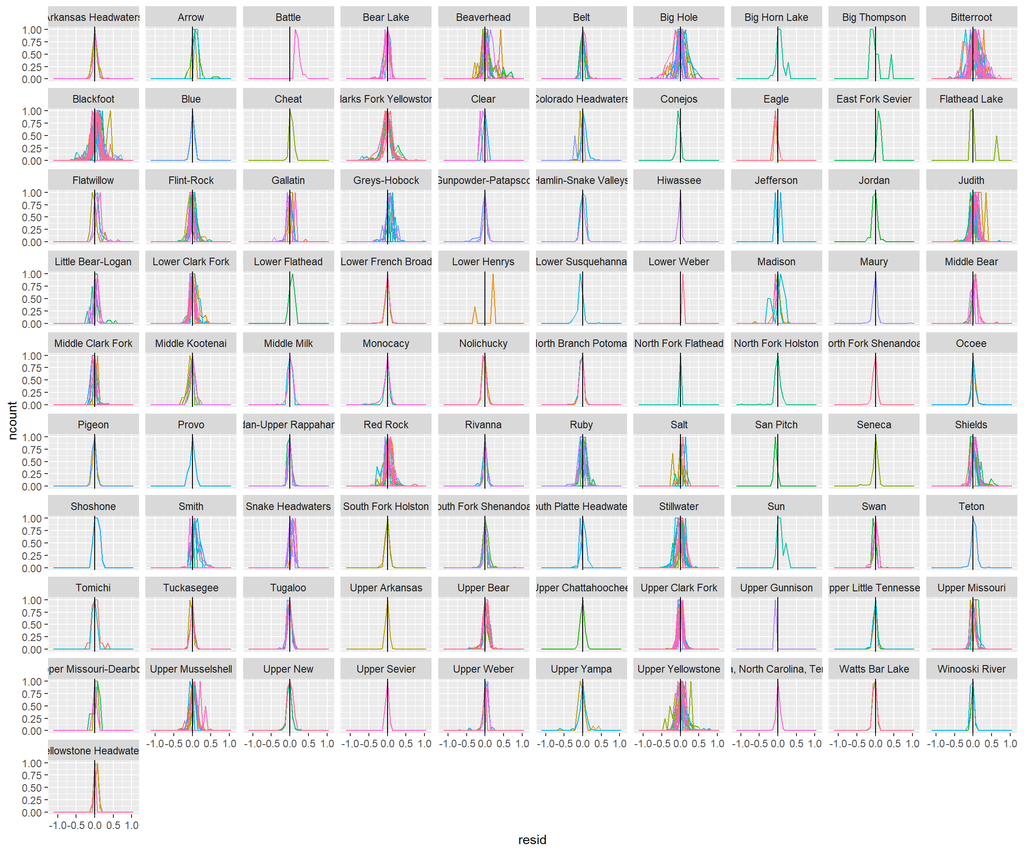

```r
ggplot(dat %>% filter(species == speciesList[1]), aes(x = resid, y = ..ncount..,
    color = HUC12_NAME)) + geom_freqpoly(nbin = 50, show.legend = FALSE) + geom_vline(xintercept = 0) +
    facet_wrap(~HUC8_Name)
```

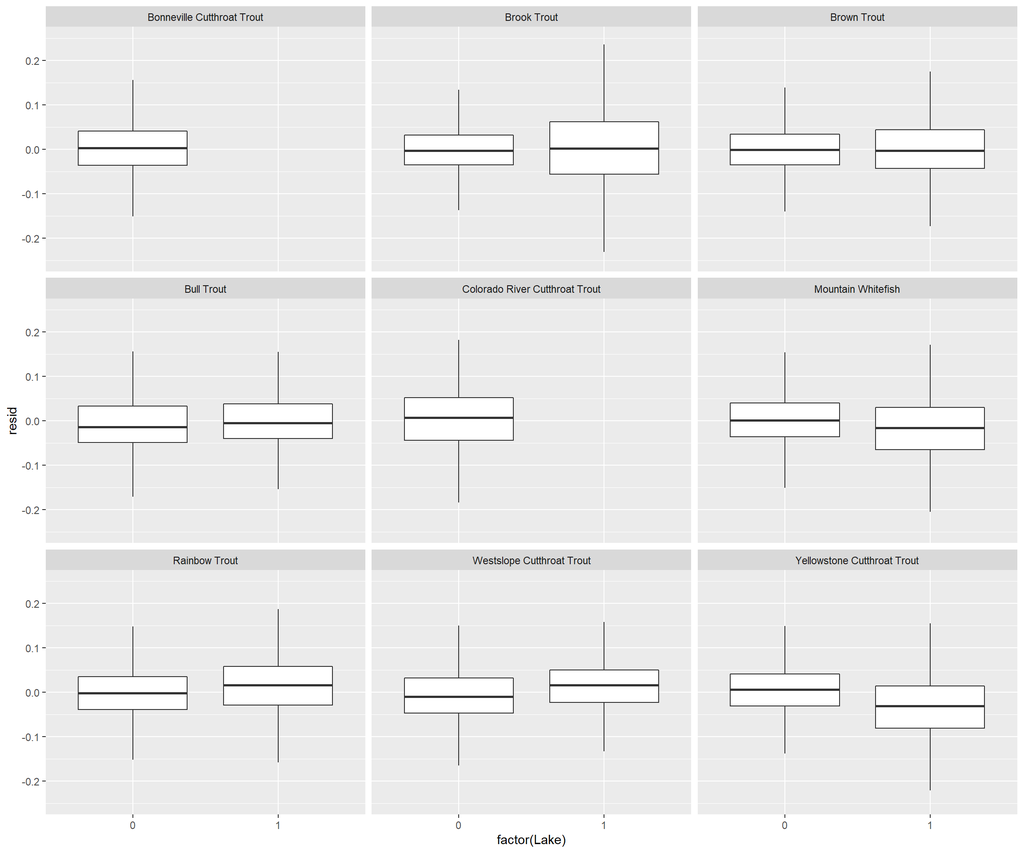

```r
# facet_wrap(~HUC12_NAME)

ggplot(dat, aes(factor(Lake), resid)) + geom_boxplot(outlier.shape = NA) + ylim(c(-0.25,
    0.25)) + facet_wrap(~species)
```

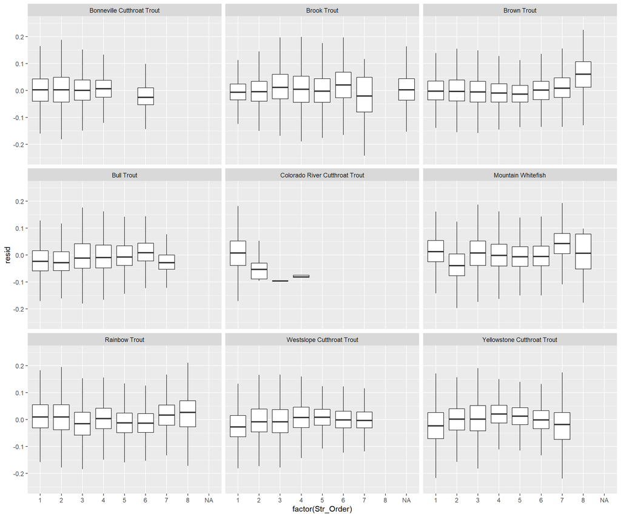

```r
ggplot(dat, aes(factor(Str_Order), resid)) + geom_boxplot(outlier.shape = NA) + ylim(c(-0.25,
    0.25)) + facet_wrap(~species)
```

```r
glance(lm(resid ~ drain_area_km2 * species, data = dat %>% filter(Lake == 0)))
```

```
## # A tibble: 1 x 11
##   r.squared adj.r.squared  sigma statistic p.value    df logLik     AIC     BIC
##       <dbl>         <dbl>  <dbl>     <dbl>   <dbl> <int>  <dbl>   <dbl>   <dbl>
## 1    0.0146        0.0145 0.0694     1893.       0    18 2.72e6 -5.44e6 -5.44e6
## # ... with 2 more variables: deviance <dbl>, df.residual <int>
```

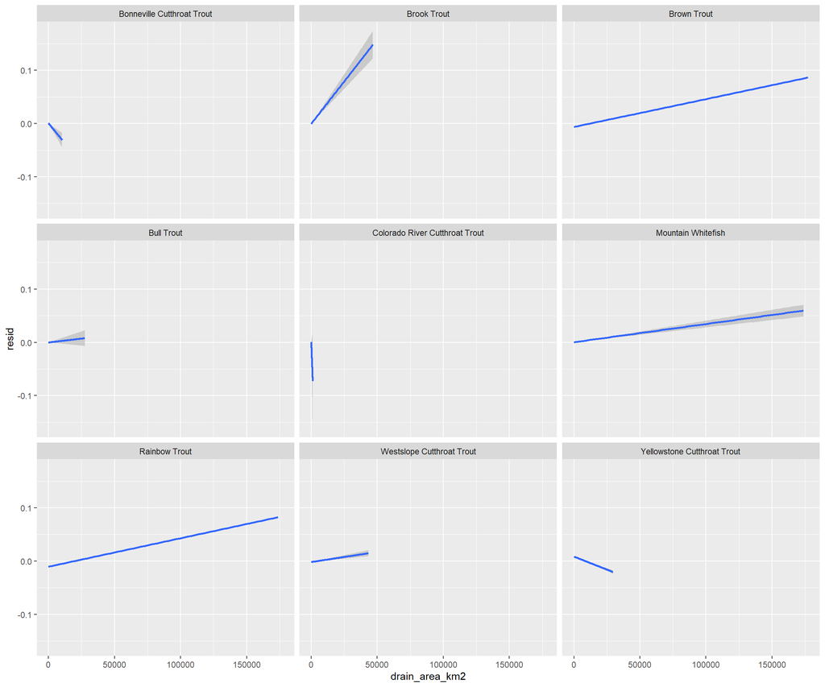

```r
ggplot(dat %>% filter(Lake == 0), aes(drain_area_km2, resid)) + # geom_point(alpha = 0.01) +
geom_smooth(method = "lm") + facet_wrap(~species)
```

```r
glance(lm(resid ~ KM_Lake * species, data = dat %>% filter(Lake == 0)))
```

```
## # A tibble: 1 x 11
##   r.squared adj.r.squared  sigma statistic p.value    df logLik     AIC     BIC
##       <dbl>         <dbl>  <dbl>     <dbl>   <dbl> <int>  <dbl>   <dbl>   <dbl>
## 1   0.00538       0.00537 0.0697      693.       0    18 2.71e6 -5.42e6 -5.42e6
## # ... with 2 more variables: deviance <dbl>, df.residual <int>
```

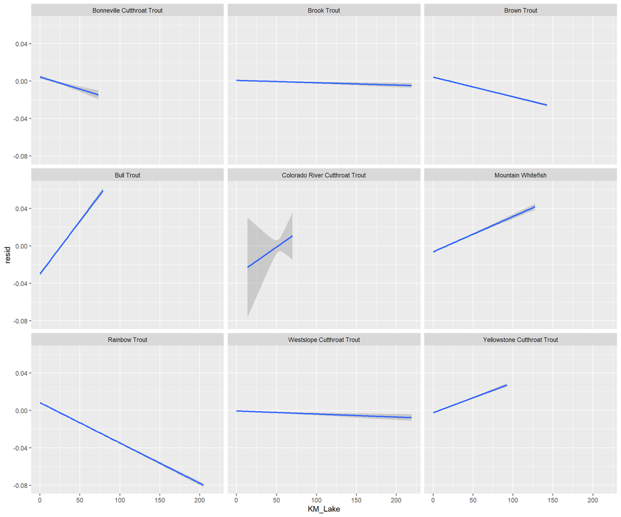

```r
ggplot(dat %>% filter(Lake == 0), aes(KM_Lake, resid)) + # geom_point(alpha = 0.01) +
geom_smooth(method = "lm") + facet_wrap(~species)
```

```r
glance(lm(resid ~ KM_5th * species, data = dat %>% filter(Lake == 0)))
```

```
## # A tibble: 1 x 11
##   r.squared adj.r.squared  sigma statistic p.value    df logLik     AIC     BIC
##       <dbl>         <dbl>  <dbl>     <dbl>   <dbl> <int>  <dbl>   <dbl>   <dbl>
## 1   0.00263       0.00262 0.0698      337.       0    18 2.71e6 -5.41e6 -5.41e6
## # ... with 2 more variables: deviance <dbl>, df.residual <int>
```

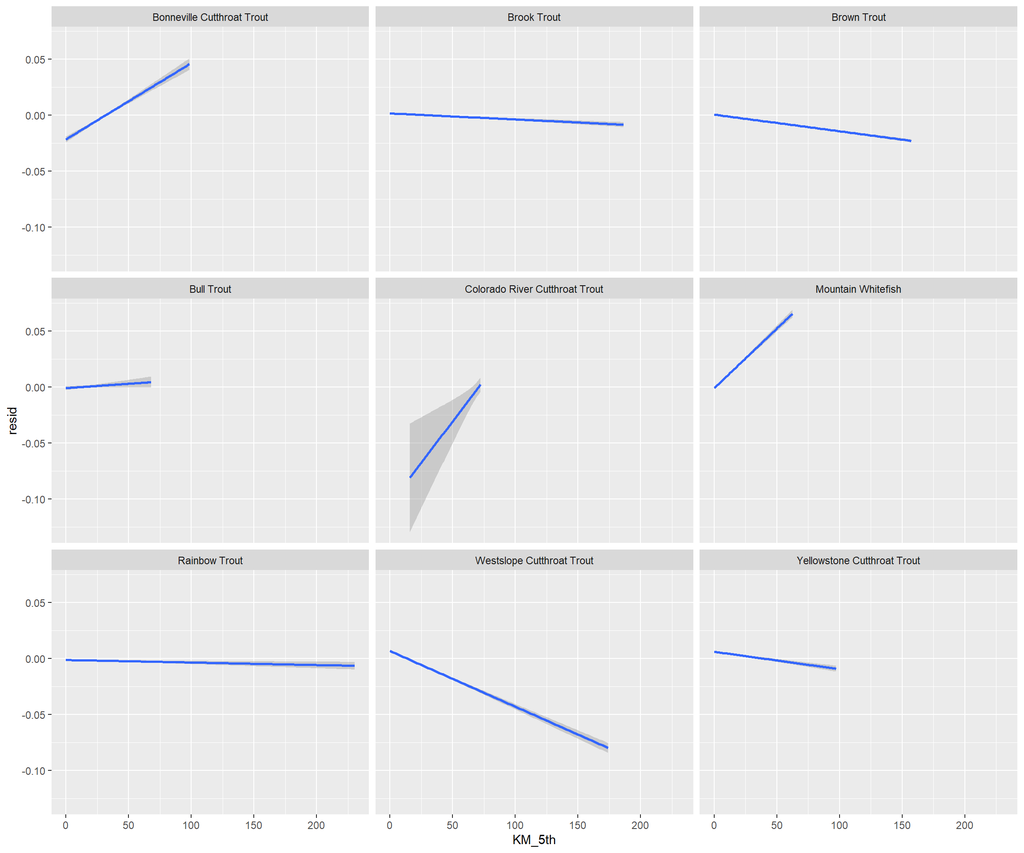

```r
ggplot(dat %>% filter(Lake == 0), aes(KM_5th, resid)) + # geom_point(alpha = 0.01) +
geom_smooth(method = "lm") + facet_wrap(~species)
```

```r
glance(lm(resid ~ springF * species, data = dat %>% filter(Lake == 0)))
```

```
## # A tibble: 1 x 11
##   r.squared adj.r.squared  sigma statistic p.value    df logLik     AIC     BIC
##       <dbl>         <dbl>  <dbl>     <dbl>   <dbl> <int>  <dbl>   <dbl>   <dbl>
## 1    0.0103        0.0103 0.0695     1333.       0    18 2.72e6 -5.43e6 -5.43e6
## # ... with 2 more variables: deviance <dbl>, df.residual <int>
```

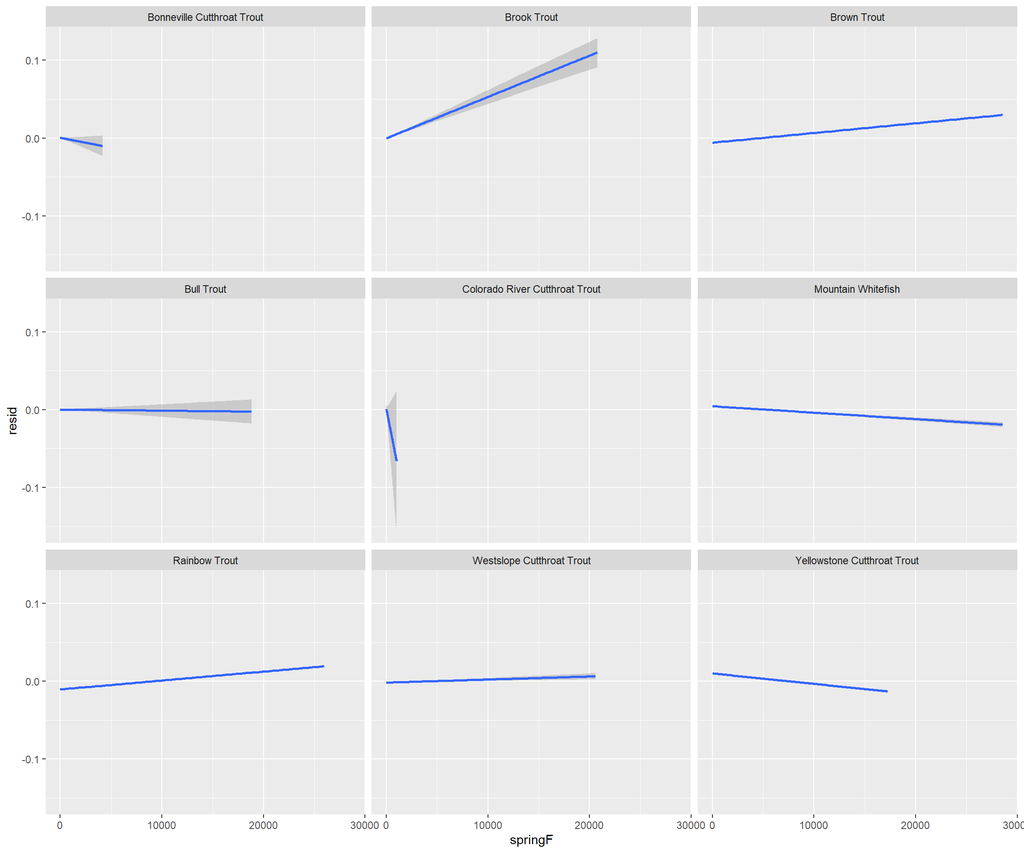

```r
ggplot(dat %>% filter(Lake == 0), aes(springF, resid)) + # geom_point(alpha = 0.01) +
geom_smooth(method = "lm") + facet_wrap(~species)
```

```r
glance(lm(resid ~ springT * species, data = dat %>% filter(Lake == 0)))
```

```
## # A tibble: 1 x 11
##   r.squared adj.r.squared  sigma statistic p.value    df logLik     AIC     BIC
##       <dbl>         <dbl>  <dbl>     <dbl>   <dbl> <int>  <dbl>   <dbl>   <dbl>
## 1   0.00424       0.00423 0.0698      546.       0    18 2.71e6 -5.42e6 -5.42e6
## # ... with 2 more variables: deviance <dbl>, df.residual <int>
```

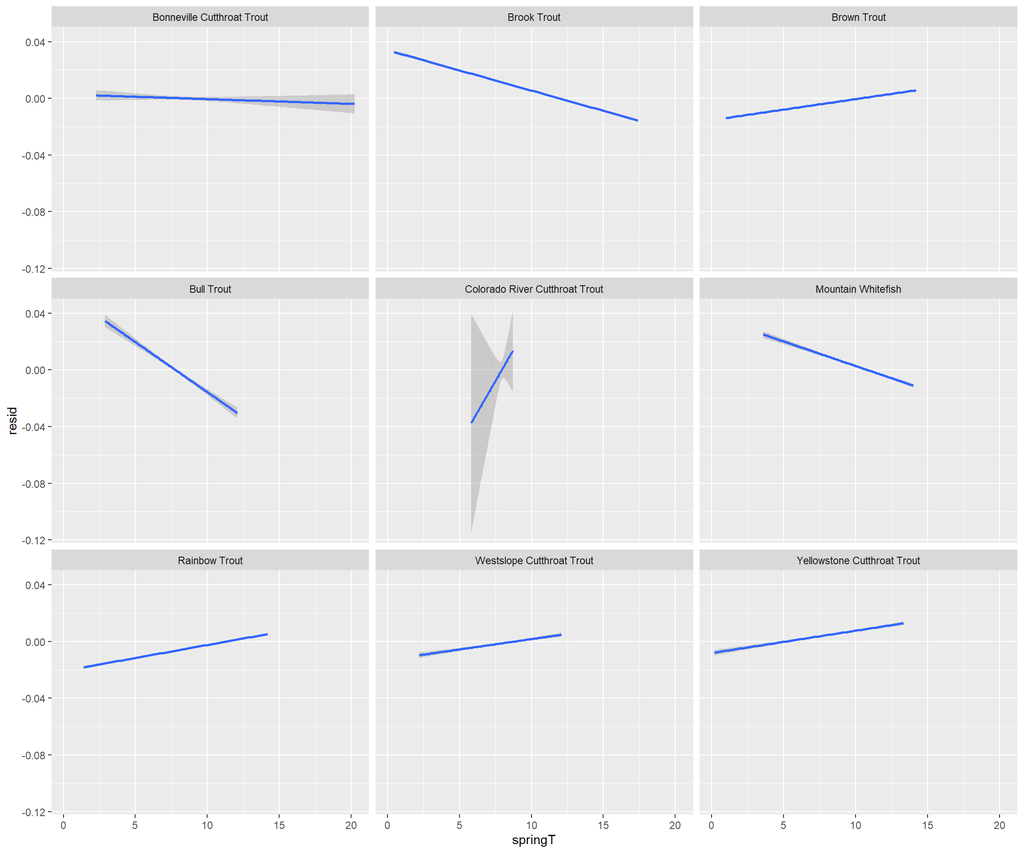

```r
ggplot(dat %>% filter(Lake == 0), aes(springT, resid)) + # geom_point(alpha = 0.01) +
geom_smooth(method = "lm") + facet_wrap(~species)
```

```r
glance(lm(resid ~ summerF * species, data = dat %>% filter(Lake == 0)))
```

```
## # A tibble: 1 x 11
##   r.squared adj.r.squared  sigma statistic p.value    df logLik     AIC     BIC
##       <dbl>         <dbl>  <dbl>     <dbl>   <dbl> <int>  <dbl>   <dbl>   <dbl>
## 1   0.00866       0.00865 0.0696     1120.       0    18 2.72e6 -5.43e6 -5.43e6
## # ... with 2 more variables: deviance <dbl>, df.residual <int>
```

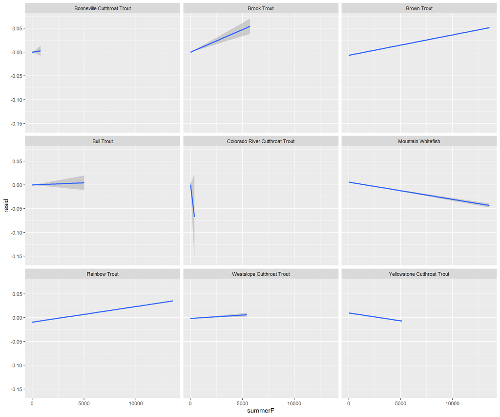

```r
ggplot(dat %>% filter(Lake == 0), aes(summerF, resid)) + # geom_point(alpha = 0.01) +
geom_smooth(method = "lm") + facet_wrap(~species)
```

```r
glance(lm(resid ~ summerT * species, data = dat %>% filter(Lake == 0)))
```

```
## # A tibble: 1 x 11
##   r.squared adj.r.squared  sigma statistic p.value    df logLik     AIC     BIC
##       <dbl>         <dbl>  <dbl>     <dbl>   <dbl> <int>  <dbl>   <dbl>   <dbl>
## 1   0.00420       0.00419 0.0698      541.       0    18 2.71e6 -5.42e6 -5.42e6
## # ... with 2 more variables: deviance <dbl>, df.residual <int>
```

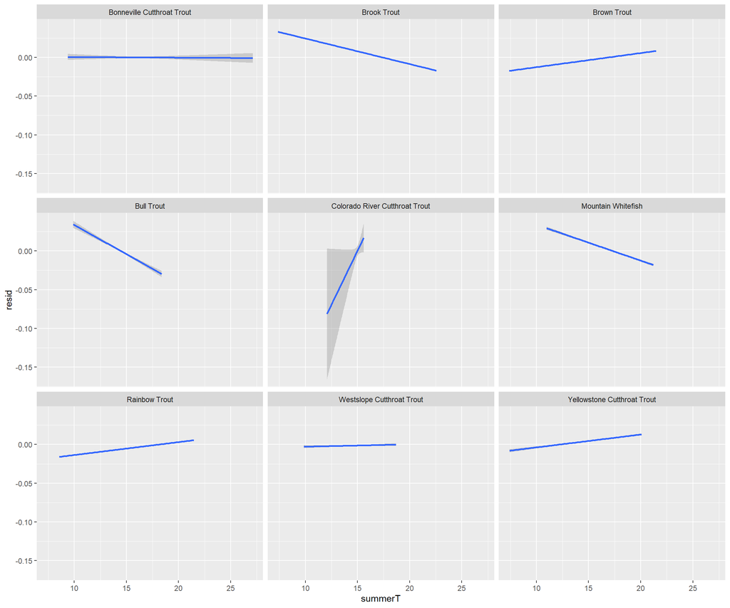

```r
ggplot(dat %>% filter(Lake == 0), aes(summerT, resid)) + # geom_point(alpha = 0.01) +
geom_smooth(method = "lm") + facet_wrap(~species)
```

```r
glance(lm(resid ~ autumnF * species, data = dat %>% filter(Lake == 0)))
```

```
## # A tibble: 1 x 11
##   r.squared adj.r.squared  sigma statistic p.value    df logLik     AIC     BIC
##       <dbl>         <dbl>  <dbl>     <dbl>   <dbl> <int>  <dbl>   <dbl>   <dbl>
## 1    0.0121        0.0121 0.0695     1575.       0    18 2.72e6 -5.44e6 -5.44e6
## # ... with 2 more variables: deviance <dbl>, df.residual <int>
```

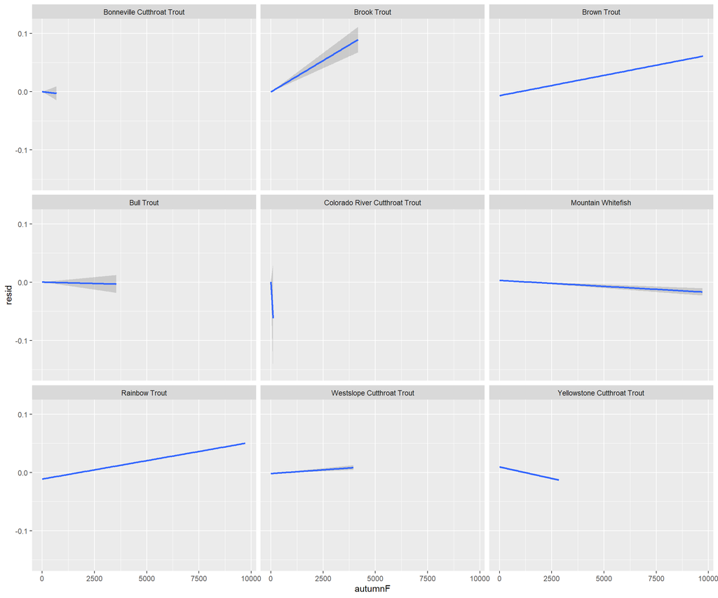

```r
ggplot(dat %>% filter(Lake == 0), aes(autumnF, resid)) + # geom_point(alpha = 0.01) +
geom_smooth(method = "lm") + facet_wrap(~species)
```

```r
glance(lm(resid ~ autumnT * species, data = dat %>% filter(Lake == 0)))
```

```
## # A tibble: 1 x 11
##   r.squared adj.r.squared  sigma statistic p.value    df logLik     AIC     BIC
##       <dbl>         <dbl>  <dbl>     <dbl>   <dbl> <int>  <dbl>   <dbl>   <dbl>
## 1   0.00466       0.00465 0.0697      601.       0    18 2.71e6 -5.42e6 -5.42e6
## # ... with 2 more variables: deviance <dbl>, df.residual <int>
```

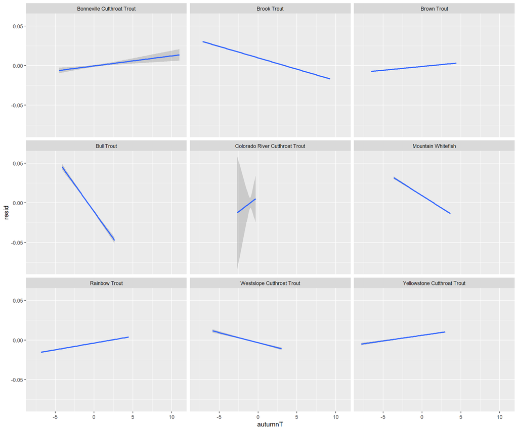

```r
ggplot(dat %>% filter(Lake == 0), aes(autumnT, resid)) + # geom_point(alpha = 0.01) +
geom_smooth(method = "lm") + facet_wrap(~species)
```

```r
glance(lm(resid ~ rel_density * species, data = dat %>% filter(Lake == 0, rel_density <
    2000)))
```

```
## # A tibble: 1 x 11
##   r.squared adj.r.squared  sigma statistic p.value    df logLik     AIC     BIC
##       <dbl>         <dbl>  <dbl>     <dbl>   <dbl> <int>  <dbl>   <dbl>   <dbl>
## 1   0.00800       0.00799 0.0693      999.       0    18 2.63e6 -5.27e6 -5.27e6
## # ... with 2 more variables: deviance <dbl>, df.residual <int>
```

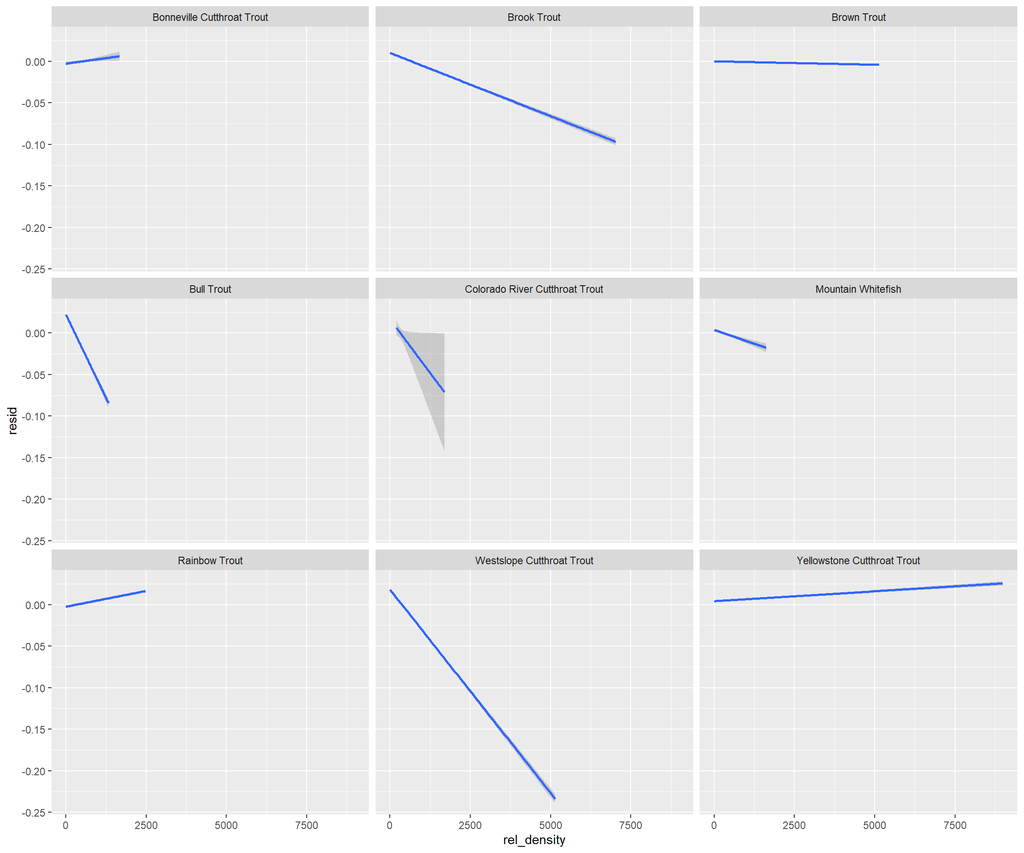

```r
ggplot(dat %>% filter(Lake == 0), aes(rel_density, resid)) + # geom_point(alpha = 0.01) +
geom_smooth(method = "lm") + facet_wrap(~species)
```

Spatially-nested lmer() by species to explore spatial structuring of variation in LW regression residuals HUC12 nested within HUC8 nested within Location

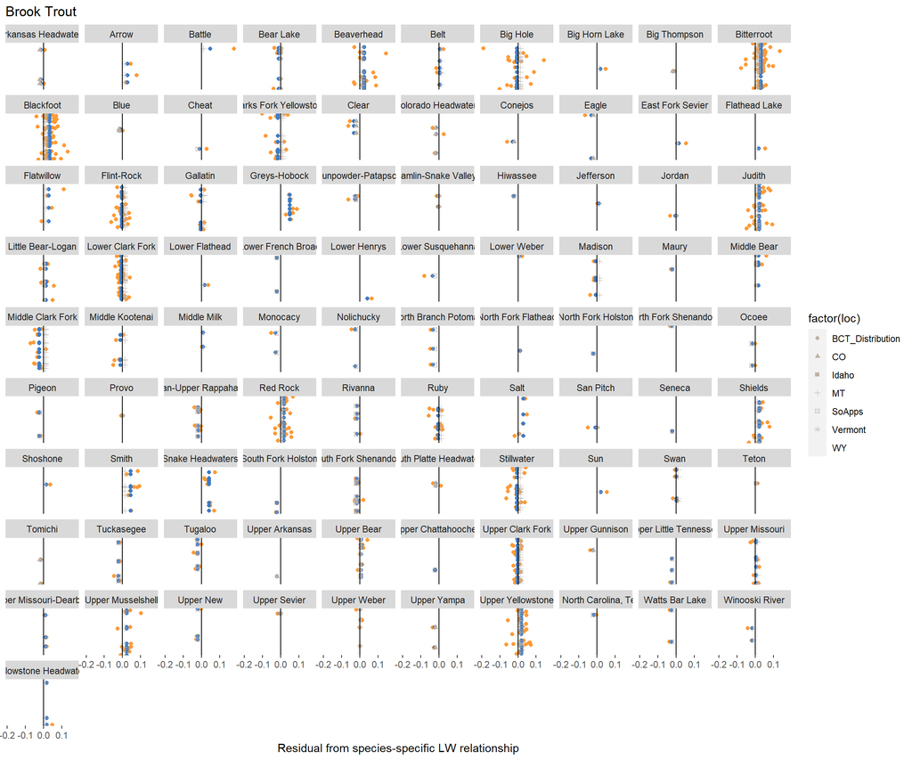

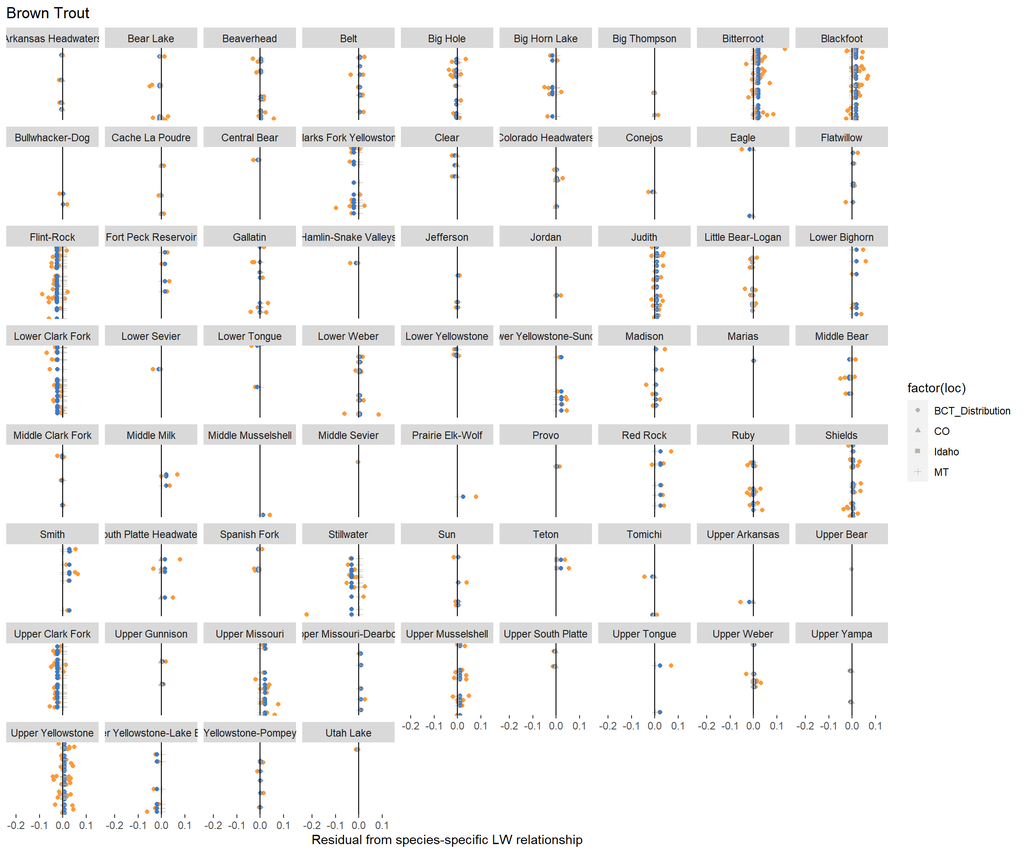

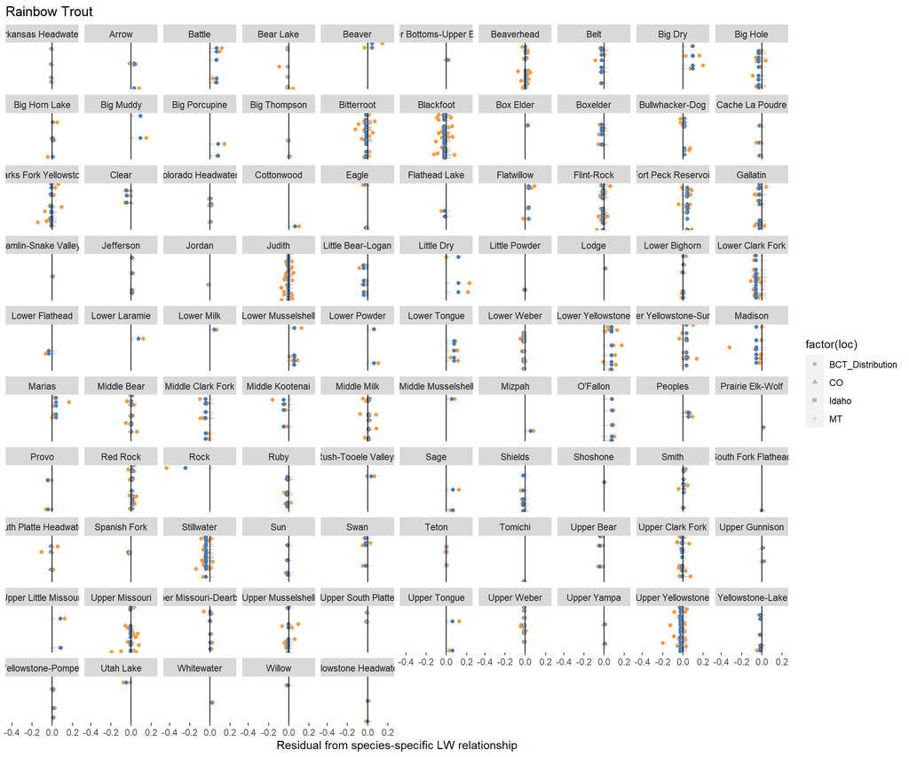

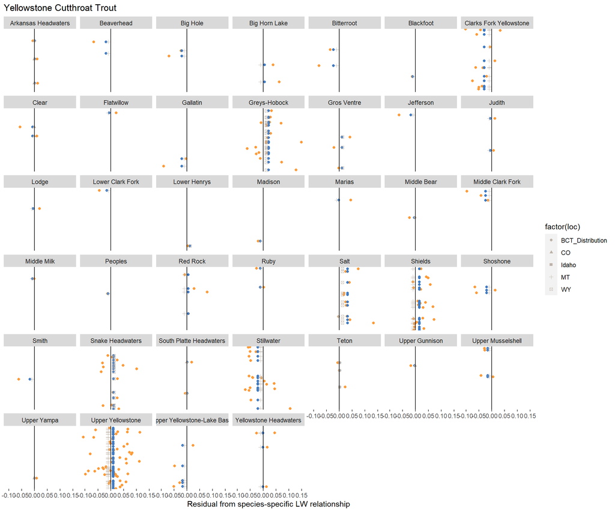

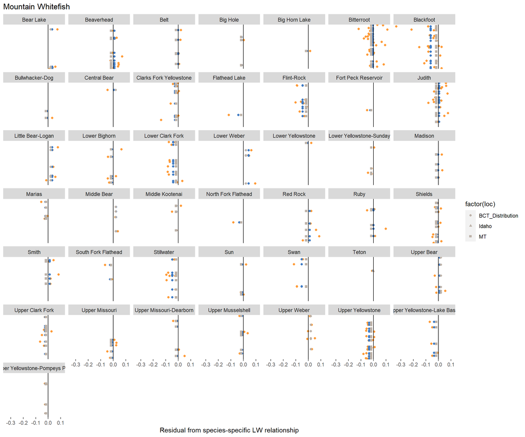

```r
# build up hierarchical random effects for each species Hierarchical graphs for
# huc12/huc8/location
lmerModel <- function(df) {
    lmer(resid ~ 1 + (1 | location/HUC8_Name/HUC12_NAME), data = df)
}

reBySpecies <- function(mod, species) {
    re <- as.data.frame(ranef(mod))

    re12 <- re %>% filter(grpvar == "HUC12_NAME:(HUC8_Name:location)") %>% mutate(huc12 = str_split(grp,
        ":", simplify = TRUE)[, 1], huc8 = str_split(grp, ":", simplify = TRUE)[,
        2], loc = str_split(grp, ":", simplify = TRUE)[, 3]) %>% rename(condval12 = condval)

    re8 <- re %>% filter(grpvar == "HUC8_Name:location") %>% mutate(loc = str_split(grp,
        ":", simplify = TRUE)[, 2], huc8 = str_split(grp, ":", simplify = TRUE)[,
        1]) %>% rename(condval8 = condval)

    reLoc <- re %>% filter(grpvar == "location") %>% mutate(loc = grp) %>% rename(condvalLoc = condval) %>%
        select(condvalLoc, loc)

    reAll1 <- left_join(re8, reLoc) %>% select(condval8, loc, huc8, condvalLoc)
    reAll <- left_join(re12, reAll1) %>% arrange(loc, huc8, huc12)
    reAll <- reAll %>% mutate(condvalLoc8 = condvalLoc + condval8, condvalLoc812 = condvalLoc +
        condval8 + condval12)

    return(reAll)
}

hierRECharts <- function(d, species) {
    gg <- ggplot(d, aes(condvalLoc812, huc12)) + geom_point(color = "#ff9a36") +
        geom_point(aes(condvalLoc8, huc12), color = "#3f7bc4") + geom_point(aes(condvalLoc,
        huc12, shape = factor(loc)), color = "#bdb2a8") + geom_vline(xintercept = 0) +
        scale_y_discrete(guide = guide_none(title = NULL)) + scale_x_continuous("Residual from species-specific LW relationship") +
        ggtitle(species) + facet_wrap(~huc8)

    ggsave(paste0("D:/projects/ecoDrought/bodySize/All_Size_inputs/ecoDrought_conditionAnalysis/charts/hierResids_",
        species, ".png"))
    return(gg)
}

## Charts of nested random effects
datBySpeciesRE <- dat %>% filter(species %in% speciesList[c(1, 3, 4, 5, 7)]) %>%
    # filter(species %in% speciesList[5]) %>% #
group_by(species) %>% nest() %>% mutate(model = map(data, lmerModel)) %>% mutate(RE = map2(model,
    species, reBySpecies)) %>% mutate(charts = map2(RE, species, hierRECharts))
datBySpeciesRE$charts
```

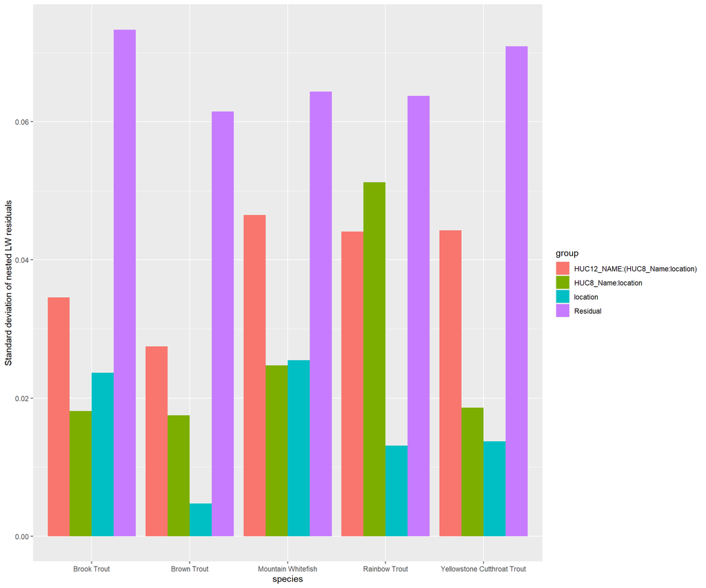

```r
## SDs of nested levels ################
datBySpeciesRESD <- datBySpeciesRE %>% mutate(tidy = map(model, broom::tidy)) %>%
    dt_unnest(tidy) %>% select(species, estimate, term, group) %>% filter(!term ==
    "(Intercept)")

ggSD <- ggplot(datBySpeciesRESD, aes(species, estimate, fill = group)) + geom_col(position = "dodge") +
    scale_y_continuous("Standard deviation of nested LW residuals")
ggSD
```

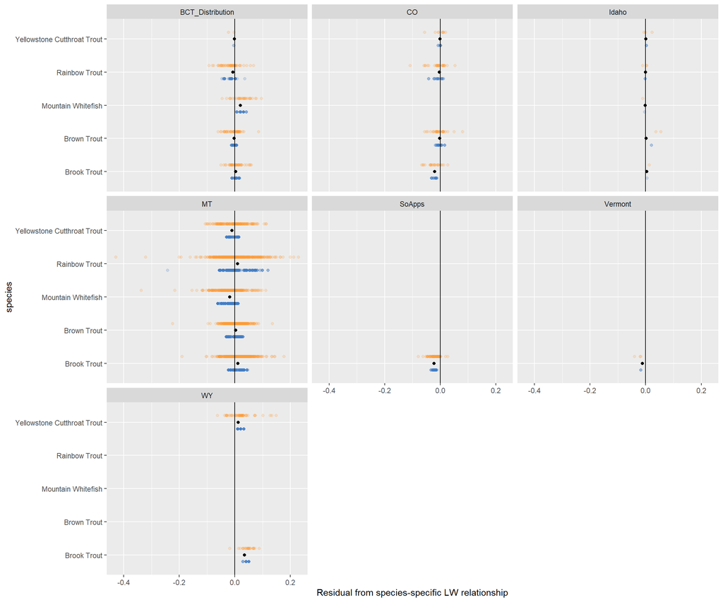

```r
## plot RE across species
datBySpeciesRE_RE <- datBySpeciesRE %>% dt_unnest(RE)

# by loc
ggplot(datBySpeciesRE_RE, aes(condvalLoc812, species)) + geom_point(color = "#ff9a36",
    alpha = 0.2, position = position_nudge(y = 0.2)) + geom_point(aes(condvalLoc8,
    species), color = "#3f7bc4", alpha = 0.2, position = position_nudge(y = -0.2)) +
    geom_point(aes(condvalLoc, species), color = "black") + geom_vline(xintercept = 0) +
    scale_x_continuous("Residual from species-specific LW relationship") + facet_wrap(~loc)
```

```r
# by huc8
nByhuc8 <- datBySpeciesRE_RE %>% group_by(huc8) %>% summarise(nSpp = length(unique(species)))
datBySpeciesRE_RE_SppN <- left_join(datBySpeciesRE_RE, nByhuc8)
```

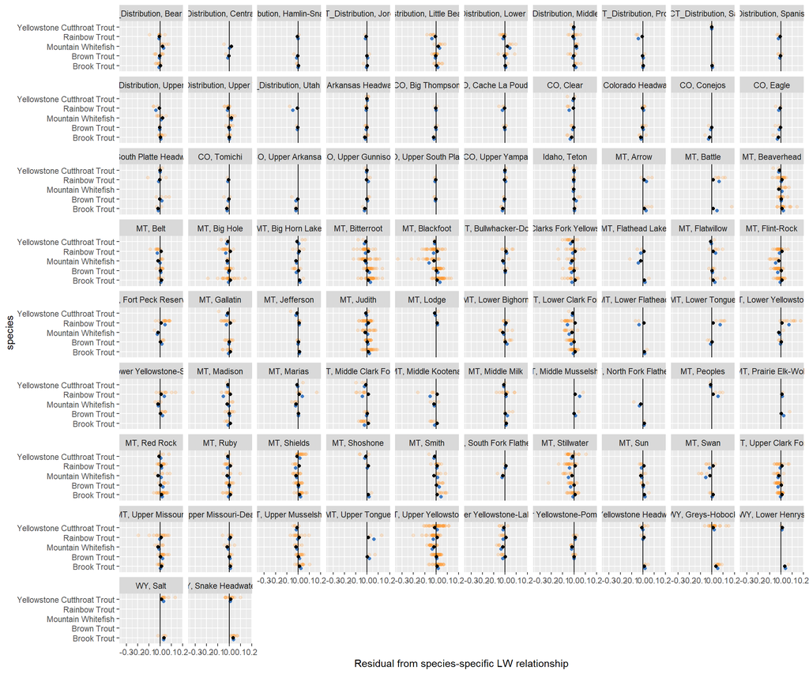

```r
ggplot(datBySpeciesRE_RE_SppN %>% filter(nSpp > 1), aes(condvalLoc812, species)) +
    geom_point(color = "#ff9a36", alpha = 0.2, position = position_nudge(y = 0.2)) +
    geom_point(aes(condvalLoc8, species), color = "#3f7bc4", position = position_nudge(y = -0.2)) +
    geom_point(aes(condvalLoc, species), color = "black") + geom_vline(xintercept = 0) +
    scale_x_continuous("Residual from species-specific LW relationship") + facet_wrap(loc ~
    huc8, labeller = labeller(.multi_line = FALSE))
```

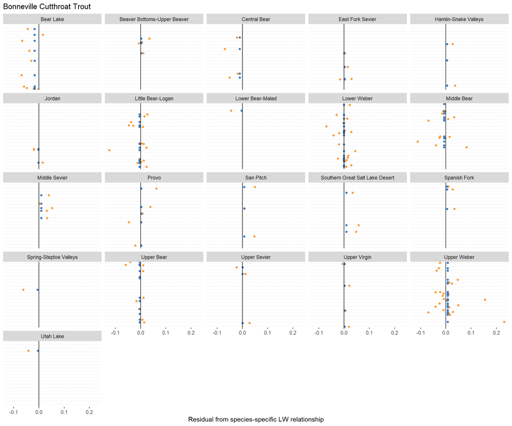

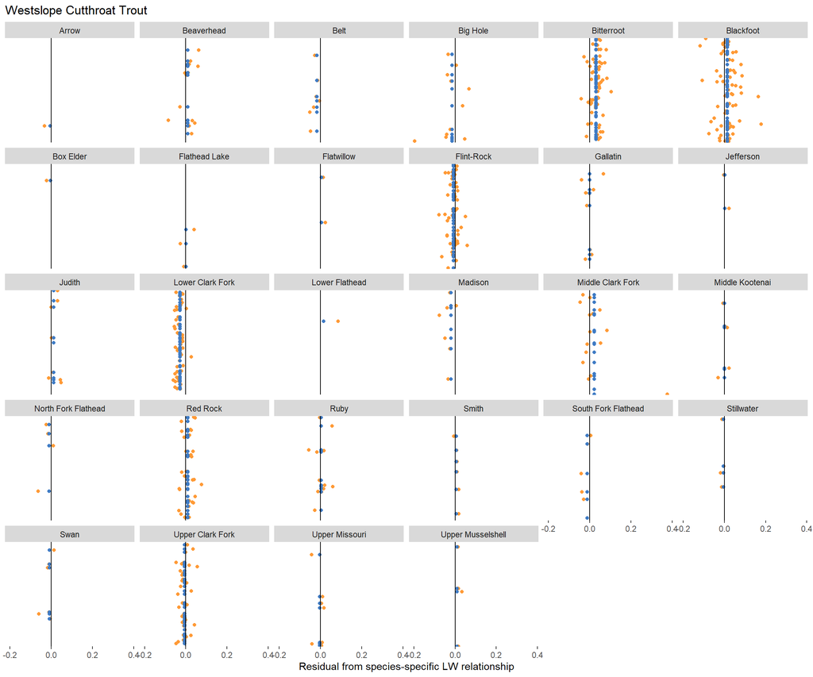

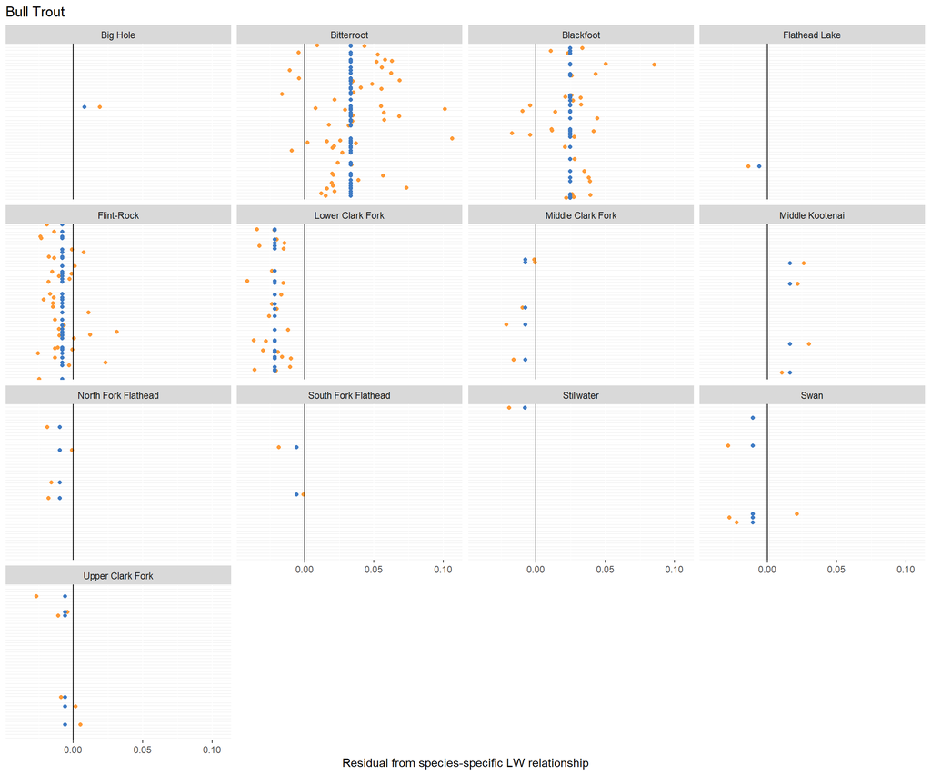

```r
############################################################################## some species have data for one location only #2 6 8 9 Colorado River Cutthroat
############################################################################## Trout model has singularity - ignoring for now Hierarchical graphs for
############################################################################## huc12/huc8

lmerModelNoLocation <- function(df) {
    lmer(resid ~ 1 + (1 | HUC8_Name/HUC12_NAME), data = df)
}

# build up hierarchical random effects for each species
reBySpecies812 <- function(mod, species) {
    re <- as.data.frame(ranef(mod))

    re12 <- re %>% filter(grpvar == "HUC12_NAME:HUC8_Name") %>% mutate(huc12 = str_split(grp,
        ":", simplify = TRUE)[, 1], huc8 = str_split(grp, ":", simplify = TRUE)[,
        2]) %>% rename(condval12 = condval)

    re8 <- re %>% filter(grpvar == "HUC8_Name") %>% mutate(huc8 = grp) %>% rename(condval8 = condval) %>%
        select(condval8, huc8)

    reAll <- left_join(re12, re8) %>% arrange(huc8, huc12)
    reAll <- reAll %>% mutate(condval8 = condval8, condval812 = condval8 + condval12)

    return(reAll)
}

hierREChartsNoLocation <- function(d, species) {
    gg <- ggplot(d, aes(condval812, huc12)) + geom_point(color = "#ff9a36") + geom_point(aes(condval8,
        huc12), color = "#3f7bc4") + geom_vline(xintercept = 0) + scale_y_discrete(guide = guide_none(title = NULL)) +
        scale_x_continuous("Residual from species-specific LW relationship") + ggtitle(species) +
        facet_wrap(~huc8)

    ggsave(paste0("D:/projects/ecoDrought/bodySize/All_Size_inputs/ecoDrought_conditionAnalysis/charts/hierResids_",
        species, ".png"))

    return(gg)
}

# Charts of nested random effects
datBySpeciesRENoLocation <- dat %>% filter(species %in% speciesList[c(2, 8, 9)]) %>%
    group_by(species) %>% nest() %>% mutate(model = map(data, lmerModelNoLocation)) %>%
    mutate(RE = map2(model, species, reBySpecies812)) %>% mutate(charts = map2(RE,
    species, hierREChartsNoLocation))
datBySpeciesRENoLocation$charts
```

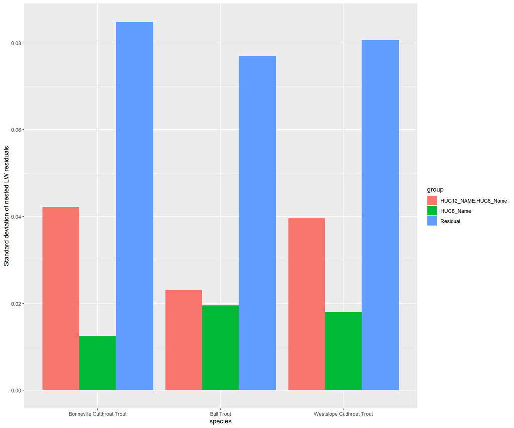

```r
## SDs of nested levels ################
datBySpeciesRENoLocationSD <- datBySpeciesRENoLocation %>% mutate(tidy = map(model,
    broom::tidy)) %>% dt_unnest(tidy) %>% select(species, estimate, term, group) %>%
    filter(!term == "(Intercept)")

ggNoLocationSD <- ggplot(datBySpeciesRENoLocationSD, aes(species, estimate, fill = group)) +
    geom_col(position = "dodge") + scale_y_continuous("Standard deviation of nested LW residuals")
ggNoLocationSD
```

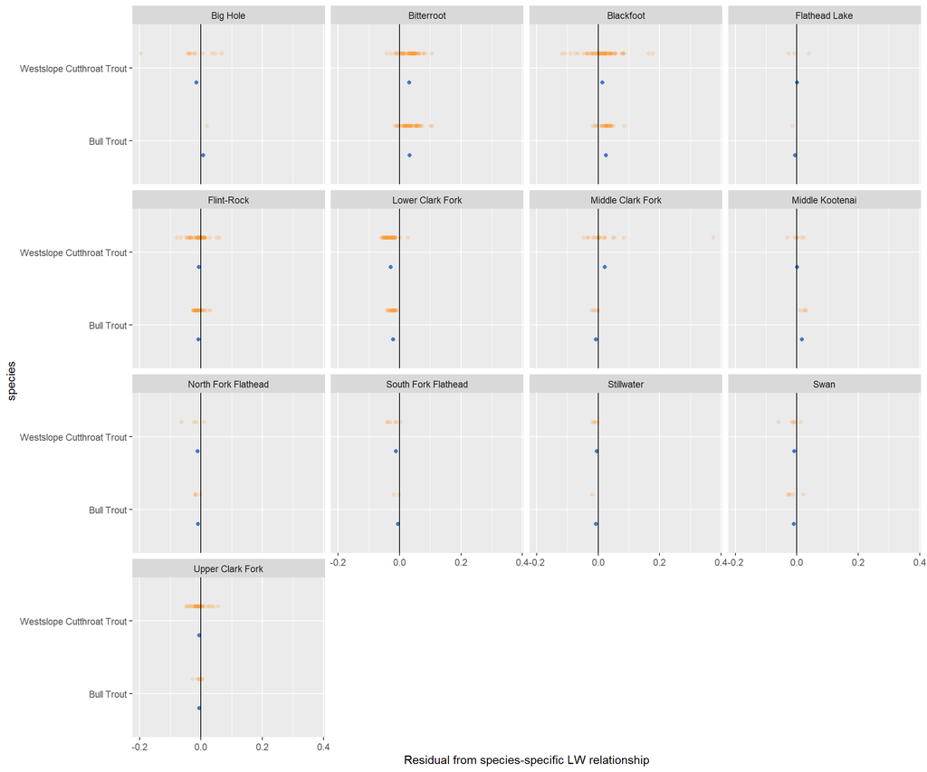

```r
## plot RE across species
datBySpeciesRENoLocation_RE <- datBySpeciesRENoLocation %>% dt_unnest(RE)

# by huc8
nNoLocationByhuc8 <- datBySpeciesRENoLocation_RE %>% group_by(huc8) %>% summarise(nSpp = length(unique(species)))
datBySpeciesRENoLocation_RE_SppN <- left_join(datBySpeciesRENoLocation_RE, nNoLocationByhuc8)
ggplot(datBySpeciesRENoLocation_RE_SppN %>% filter(nSpp > 1), aes(condval812, species)) +
    geom_point(color = "#ff9a36", alpha = 0.2, position = position_nudge(y = 0.2)) +
    geom_point(aes(condval8, species), color = "#3f7bc4", position = position_nudge(y = -0.2)) +
    geom_vline(xintercept = 0) + scale_x_continuous("Residual from species-specific LW relationship") +
    facet_wrap(~huc8)
```

# Residual means by waterbody

Analyze means of residuals by waterbody. Speeds up lmer() and reduces df inflation from individual observations. Remove waterbodies with < 10 observations. Look in depth at lm() for Brook Trout

```r
datByWB <- dat %>% group_by(species, Lake, WATERBODY, location, HUC8_Name, HUC12_NAME,
    rdStd, rel_density, sFStd, sTStd, daStd, Str_Order, KM_4th, KM_Lake) %>% summarize(meanResid = mean(resid,
    na.rm = TRUE), sdResid = sd(resid, na.rm = TRUE), n = n(), meanLength = mean(log10Length,
    na.rm = TRUE), meanWeight = mean(log10Weight, na.rm = TRUE)) %>% filter(n > 10) %>%
    ungroup()
## bkt deep dive
datBKT <- datByWB %>% filter(species == "Brook Trout")

b0 <- lmer(meanResid ~ 1 + (1 | location/HUC8_Name), data = datBKT %>% filter(Lake ==
    0))
b1 <- lmer(meanResid ~ 1 + rdStd + (1 | location/HUC8_Name), data = datBKT %>% filter(Lake ==
    0))

AIC(b0, b1)
```

```
##    df       AIC
## b0  4 -4173.528
## b1  5 -4128.903
```

```r
tidy(b1)
```

```
## # A tibble: 5 x 5
##   term                            estimate std.error statistic group
##   <chr>                              <dbl>     <dbl>     <dbl> <chr>
## 1 (Intercept)                      0.00789   0.0102      0.771 fixed
## 2 rdStd                           -0.00480   0.00129    -3.72  fixed
## 3 sd_(Intercept).HUC8_Name:locat~  0.0146   NA          NA     HUC8_Name:locati~
## 4 sd_(Intercept).location          0.0231   NA          NA     location
## 5 sd_Observation.Residual          0.0418   NA          NA     Residual
```

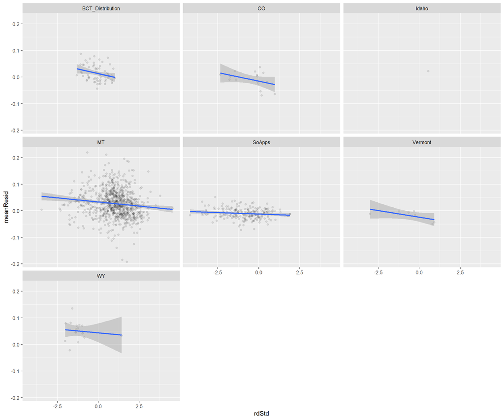

```r
ggplot(datBKT %>% filter(Lake == 0), aes(rdStd, meanResid)) + geom_point(alpha = 0.1) +
    geom_smooth(method = "lm") + facet_wrap(~location)
```

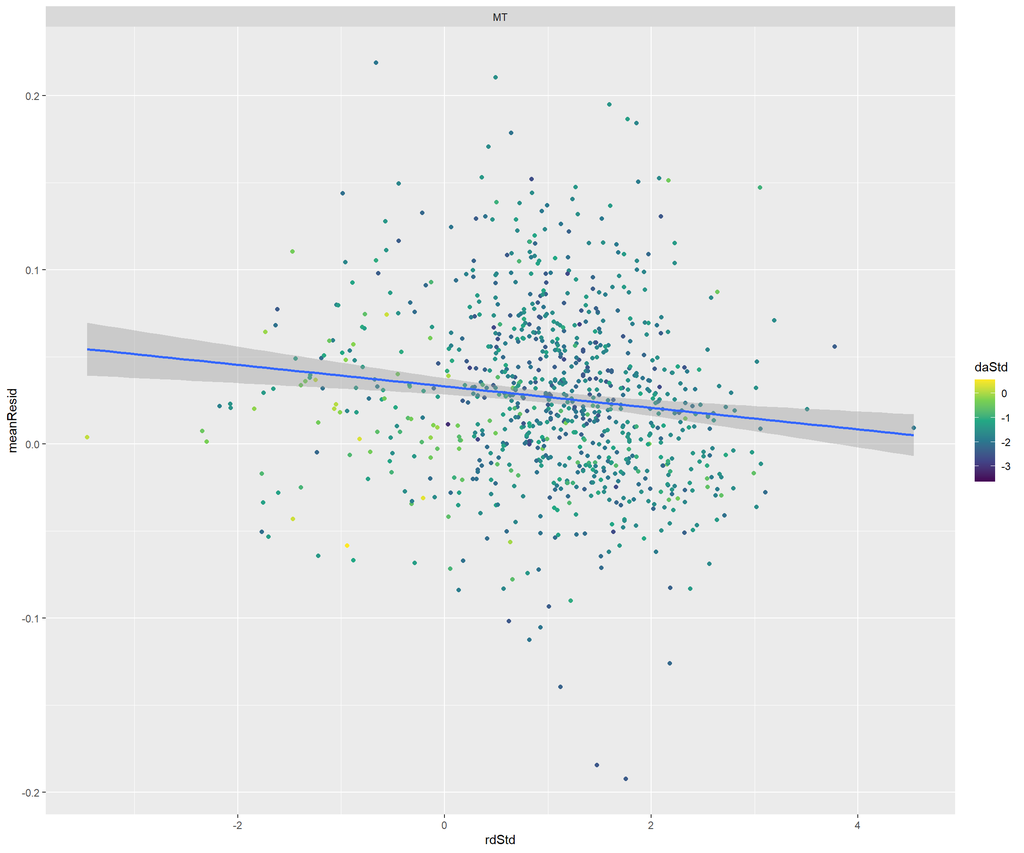

```r
# summerF, summerT, drain_area_km2, Str_Order, KM_4th,KM_Lake
ggplot(datBKT %>% filter(Lake == 0, location == "MT"), aes(rdStd, meanResid)) + geom_point(aes(color = daStd)) +
    geom_smooth(method = "lm") + scale_color_viridis_c() + facet_wrap(~location)
```

```r
b2 <- lmer(meanResid ~ 1 + daStd + (1 | location/HUC8_Name), data = datBKT %>% filter(Lake ==
    0))
b3 <- lmer(meanResid ~ 1 + daStd * rdStd + (1 | location/HUC8_Name), data = datBKT %>%
    filter(Lake == 0))

AIC(b0, b1, b2, b3)
```

```
##    df       AIC
## b0  4 -4173.528
## b1  5 -4128.903
## b2  5 -4162.519
## b3  7 -4108.610
```

```r
glance(b3)
```

```
## # A tibble: 1 x 6
##    sigma logLik    AIC    BIC deviance df.residual
##    <dbl>  <dbl>  <dbl>  <dbl>    <dbl>       <int>
## 1 0.0417  2061. -4109. -4073.   -4164.        1196
```

```r
b4 <- lmer(meanResid ~ 1 + daStd * meanLength + (1 | location/HUC8_Name), data = datBKT %>%
    filter(Lake == 0))
AIC(b0, b1, b2, b3, b4) %>% arrange(AIC)
```

```
##    df       AIC
## b0  4 -4173.528
## b2  5 -4162.519
## b4  7 -4156.067
## b1  5 -4128.903
## b3  7 -4108.610
```

```r
# are the random effects sucking up all the variance? Try just lm() to see how
# var can get explained
blm0 <- lm(meanResid ~ 1, data = datBKT %>% filter(Lake == 0))
blm1 <- lm(meanResid ~ 1 + location, data = datBKT %>% filter(Lake == 0))
blm2 <- lm(meanResid ~ 1 + rdStd * location, data = datBKT %>% filter(Lake == 0))
blm3 <- lm(meanResid ~ 1 + daStd * location, data = datBKT %>% filter(Lake == 0))
blm4 <- lm(meanResid ~ 1 + sFStd * location, data = datBKT %>% filter(Lake == 0))
blm5 <- lm(meanResid ~ 1 + sTStd * location, data = datBKT %>% filter(Lake == 0))
blm6 <- lm(meanResid ~ 1 + meanLength * location, data = datBKT %>% filter(Lake ==
    0))
blm7 <- lm(meanResid ~ 1 + Str_Order * location, data = datBKT %>% filter(Lake ==
    0))
blm8 <- lm(meanResid ~ 1 + KM_4th * location, data = datBKT %>% filter(Lake == 0))
blm9 <- lm(meanResid ~ 1 + rdStd * daStd * location, data = datBKT %>% filter(Lake ==
    0))
blm10 <- lm(meanResid ~ 1 + sFStd * sTStd * location, data = datBKT %>% filter(Lake ==
    0))
blm11 <- lm(meanResid ~ 1 + meanLength * sFStd * location, data = datBKT %>% filter(Lake ==
    0))
blm12 <- lm(meanResid ~ 1 + meanLength * sTStd * location, data = datBKT %>% filter(Lake ==
    0))
blm13 <- lm(meanResid ~ 1 + meanLength * sFStd * sTStd * location, data = datBKT %>%
    filter(Lake == 0))
blmMega <- lm(meanResid ~ 1 + meanLength * sFStd * sTStd * Str_Order * KM_4th * location *
    sFStd * sTStd, data = datBKT %>% filter(Lake == 0))

AIC(blm0, blm1, blm2, blm3, blm4, blm5, blm6, blm7, blm8, blm9, blm10, blm11, blm12,
    blm13, blmMega) %>% arrange(AIC)
```

```
##          df       AIC
## blm10    26 -4103.518
## blm6     14 -4099.188
## blm1      8 -4097.288
## blm4     14 -4096.654
## blm5     14 -4096.286
## blm3     14 -4089.110
## blm12    26 -4086.319
## blm11    26 -4083.164
## blm13    50 -4081.617
## blm7     14 -4072.272
## blm9     26 -4068.393
## blm2     14 -4064.834
## blm8     14 -4061.836
## blm0      2 -3977.756
## blmMega 140 -3932.943
```

```r
glance(blm10)
```

```
## # A tibble: 1 x 11
##   r.squared adj.r.squared  sigma statistic  p.value    df logLik    AIC    BIC
##       <dbl>         <dbl>  <dbl>     <dbl>    <dbl> <int>  <dbl>  <dbl>  <dbl>
## 1     0.132         0.115 0.0447      7.62 2.72e-24    25  2078. -4104. -3971.
## # ... with 2 more variables: deviance <dbl>, df.residual <int>
```

```r
glance(blm13)
```

```
## # A tibble: 1 x 11
##   r.squared adj.r.squared  sigma statistic  p.value    df logLik    AIC    BIC
##       <dbl>         <dbl>  <dbl>     <dbl>    <dbl> <int>  <dbl>  <dbl>  <dbl>
## 1     0.151         0.116 0.0447      4.34 1.03e-19    49  2091. -4082. -3826.
## # ... with 2 more variables: deviance <dbl>, df.residual <int>
```

```r
glance(blmMega)
```

```
## # A tibble: 1 x 11
##   r.squared adj.r.squared  sigma statistic p.value    df logLik    AIC    BIC
##       <dbl>         <dbl>  <dbl>     <dbl>   <dbl> <int>  <dbl>  <dbl>  <dbl>
## 1     0.204         0.102 0.0452      1.99 1.72e-9   139  2106. -3933. -3219.
## # ... with 2 more variables: deviance <dbl>, df.residual <int>
```

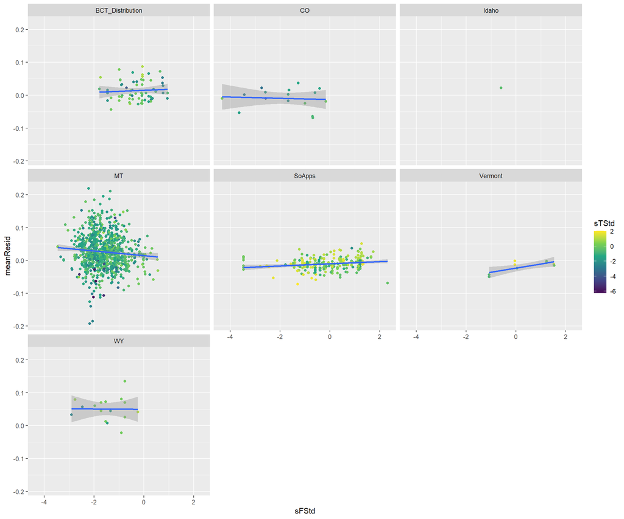

```r
ggplot(datBKT %>% filter(Lake == 0), aes(sFStd, meanResid)) + geom_point(aes(color = sTStd)) +
    geom_smooth(method = "lm") + scale_color_viridis_c() + facet_wrap(~location)
```

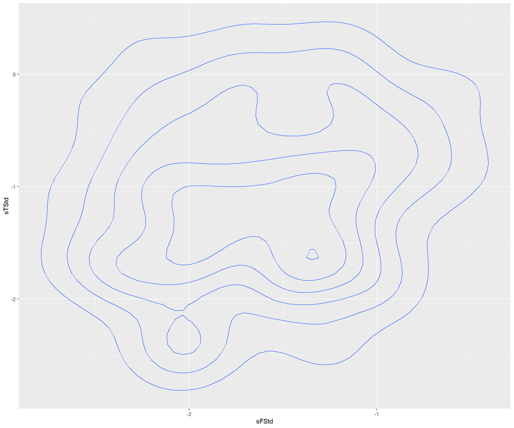

```r
ggplot(datBKT %>% filter(Lake == 0, location == "MT"), aes(sFStd, sTStd, z = meanResid)) +
    geom_density2d()
```